# Migration Experiment_01-Data-Exploration

# I. Setup

## I.A. Libraries and Load Data

## I.B. Useful Reference Values

```r
# Metadata
num_checklists = n_distinct(checklists_EXP$Checklist.ID)
num_pairs = n_distinct(checklists_EXP$Date)
obs_dates = unique(checklists_EXP$Day)


# List of Species
species_order <- my_tax_EXP %>% arrange(Taxonomy) %>% pull(Species)
num_species = length(species_order)
```

## I.D. Add Population column

“Population” is the max count for each particular day (defined in my filter function)

Adding to overall myebird_EXP dataframe, but if the filter function is used, it will be recalculated within the function

```r
myebird_EXP <- myebird_EXP %>% group_by(Date, Species) %>%
    mutate(Population = max(Count), .after = Count) %>% ungroup()
```

## I.E. Add Species Groups to myebird_EXP; Make Species and Groups factors

```r
# Add Species Groups to myebird_EXP
my_tax_EXP_join <- my_tax_EXP %>% select(Species, Species.Group)

myebird_EXP <- left_join(myebird_EXP, my_tax_EXP_join, by = "Species") %>%
  relocate(Species.Group, .after = Species)

# make Species and Groups factors
#... for myebird_EXP
myebird_EXP <- myebird_EXP %>% mutate(
  Species = factor(Species, levels = my_tax_EXP$Species),
  Species.Group = factor(Species.Group, levels = unique(my_tax_EXP$Species.Group)))
#... and for mytaxonomy
my_tax_EXP <- my_tax_EXP %>% mutate(
  Species = factor(Species, levels = my_tax_EXP$Species),
  Species.Group = factor(Species.Group, levels = unique(my_tax_EXP$Species.Group)))
```

## I.F. Functions

```r
# ---- # MY FILTER FUNCTION ----
# - "keep": can select character vectors and/or specific species strings to keep
#        - eg keep = c(vec1, "species1")
# - "group": associated with "Species.Group", which is a grouping of convenience for graphing, NOT a precise phylogenetic grouping
# - "complete" and "paired" : pass TRUE/FALSE to function, if statement clears only if TRUE is passed, THEN filter is applied.
#        - This shouldn't be necessary since dataframes are already segregated (myebird_EXP, myebird_EXP_extra_obs)
# - this function uses "my_tax_EXP" dataframe defined in setup chunk, outside of this function

my_filter <- function(df,
                      complete = NULL, paired = NULL,
                      keep = NULL, drop = NULL,
                      group_keep = NULL, group_drop = NULL,
                      time_bin_keep = NULL,
                      date_drop = NULL) {


  # Fold group_keep into keep
  if(!is.null(group_keep)) {
    group_sp <- my_tax_EXP %>% filter(Species.Group %in% group_keep) %>% pull(Species) %>% as.character()
    keep = c(keep, group_sp) }

  # Fold group_drop into drop
  if (!is.null(group_drop)) {
    group_sp <- my_tax_EXP %>% filter(Species.Group %in% group_drop) %>% pull(Species) %>% as.character()
    drop = c(drop, group_sp) }


  # Save "df" argument as "result" so that it has a different name after all the filtering
  result <- df

  if(!is.null(complete))                result <- filter(result, Is.Complete == complete)
  if(!is.null(paired))                  result <- filter(result, Is.Paired == paired)
  if(!is.null(keep))          result <- filter(result, Species %in% keep)
  if(!is.null(drop))          result <- filter(result, !(Species %in% drop))
  # don't actually need the parentheses for !(Species %in% drop), bc !Species doesn't make sense, but !Boolean does
  if(!is.null(time_bin_keep)) result <- filter(result, Start.Time.Bin %in% time_bin_keep)
  if(!is.null(date_drop))     result <- filter(result, !(Date %in% date_drop))

 # result <- result %>% group_by(Date, Species) %>%
  #  mutate(Population = max(Count), .after = Count) %>% ungroup()

  result
}
```

```r
# ---- 0. REGION POLYGON: needed as the default `region_poly` for
# get_expected_abundance() below. Local County is loaded once here,
# then reprojected to match the CRS used by eBird's abundance rasters
# (we load one raster, "yerwar", purely to read its CRS off of it).
local_county <- counties(state = "MA", cb = TRUE, progress_bar = FALSE) %>%  # real state/county needed to query tigris; renamed for the public repo
  filter(NAME == "Suffolk")
```

```r
abd <- load_raster("yerwar", product = "abundance", resolution = "27km")

local_county_v <- vect(local_county)
local_county_v <- project(local_county_v, crs(abd))   # match raster's CRS


# DOWNLOAD SPECIES ABUNDANCE DATA AND MAKE 3-PART GRAPH

# ---- 1. FUNCTION DEFINITION: one species -> expected abundance curve ----
# manual overrides for species whose codes don't match my taxonomy df --
# ebirdst's models predate these eBird taxonomy splits, so it only has data
# under the pre-split/combined code
code_overrides <- c(
  "Eastern Warbling Vireo"  = "warvir",   # ebirdst has no Eastern/Western split
  "Northern House Wren"     = "y01309",   # ebirdst has no Northern/Southern split -- "houwre" doesn't exist
  "Northern Yellow Warbler" = "yelwar"    # ebirdst has no Northern split -- "yelwar1" doesn't exist
)
get_expected_abundance <- function(species_common_name,
                                   taxonomy_df = my_tax_EXP,
                                   region_poly = local_county_v,
                                   months_keep = c(3,4,5,6)) {
  code <- if (species_common_name %in% names(code_overrides)) {
    code_overrides[[species_common_name]]          # override wins if present
  } else {
    taxonomy_df %>% filter(Species == species_common_name) %>% pull(Species.Code)
  }
  # FIXED GUARD: catches NA, empty, and multi-match
  if (length(code) != 1 || is.na(code) || code == "") {
    warning("No usable species code for: ", species_common_name); return(NULL)
  }
  result <- try({
    # pattern restricts the download to just the one weekly 27km median
    # raster load_raster() below actually reads, instead of all ~28 files
    # (every period/metric/resolution combo) download_abundance=TRUE pulls by default
    ebirdst_download_status(species = code, pattern = "abundance_median_27km")
    load_raster(code, product = "abundance", resolution = "27km")
  }, silent = TRUE)
  if (inherits(result, "try-error")) {             # keeps one bad species from killing the whole run
    warning("Download/load failed for: ", species_common_name, " (", code, ")")
    return(NULL)
  }
  vals <- as.numeric(extract(result, region_poly, fun = mean, na.rm = TRUE)[1, -1])
  data.frame(Species = species_common_name,
             date = as.Date(names(result)),
             expected_abundance = vals) %>%
    filter(month(date) %in% months_keep) %>%
    mutate(yday = yday(date))
}


# ---- 2. FUNCTION DEFINITION: SHARED PLOT SETUP ----

# now a FUNCTION, since the x-range varies by species
align_layers <- function(rng) {
  list(
    geom_vline(xintercept = obs_yday, color = "grey65", linewidth = 0.3, linetype = "dotted"),
    annotate("rect", xmin = -Inf, xmax = min(obs_yday), ymin = -Inf, ymax = Inf,
             fill = "grey85", alpha = 0.4),
    annotate("rect", xmin = max(obs_yday), xmax = Inf, ymin = -Inf, ymax = Inf,
             fill = "grey85", alpha = 0.4),
    scale_x_continuous(breaks = month_breaks, labels = month_labels),
    coord_cartesian(xlim = rng)          # crops the view without dropping rows (no warnings)
  )
}

# ---- 3. FUNCTION DEFINITION: one species -> stacked 2-panel figure (Expected Abundance, Observed Counts) ----
make_2panel <- function(sp) {
  exp_sp <- expected_all %>% filter(Species == sp)
  if (nrow(exp_sp) == 0) return(NULL)              # skip species that failed lookup

  rng <- if (!is.null(range_overrides[[sp]])) range_overrides[[sp]] else default_range

  p1 <- ggplot(exp_sp, aes(x = yday, y = expected_abundance)) +
    geom_line() + geom_point() +
    align_layers(rng) +
    labs(title = sp, subtitle = "Expected regional abundance (eBird 2023 modeled estimate)", x = NULL, y = "Expected") +
    theme_minimal() + story_theme_sizes

  p2 <- myebird_EXP %>% filter(Species == sp) %>%
    mutate(yday = yday(Date)) %>%
    ggplot(aes(x = yday, y = Population)) +
    # same styling as the Observed line in VI.C.4/VI.D.5 (Observed vs Expected)
    geom_line(linetype = "dashed", color = "#1B7837", linewidth = 0.5) +
    geom_point(color = "#1B7837", size = 0.8) +
    geom_rug(sides = "b", length = unit(0.04, "npc")) +
    align_layers(rng) +
    labs(subtitle = "Your observed counts (dashed = interpolated between visits)",
         x = NULL, y = "Count") +
    theme_minimal() + story_theme_sizes

  p1 / p2
}

# ---- 4. FUNCTION DEFINITION: one species -> stacked 3-panel figure (Expected Abundance, Birdcast, Observed Counts) ----
make_3panel <- function(sp) {
  exp_sp <- expected_all %>% filter(Species == sp)
  if (nrow(exp_sp) == 0) return(NULL)              # skip species that failed lookup

  rng <- if (!is.null(range_overrides[[sp]])) range_overrides[[sp]] else default_range

  p1 <- ggplot(exp_sp, aes(x = yday, y = expected_abundance)) +
    geom_line() + geom_point() +
    align_layers(rng) +
    labs(title = sp, subtitle = "Expected regional abundance (eBird 2023 modeled estimate)", x = NULL, y = "Expected") +
    theme_minimal() + story_theme_sizes


  p2 <- birdcast %>%
    ggplot(aes(x = yday, y = Average.Birds.in.Flight)) +
    geom_line() + geom_point() +
    align_layers(rng) +
    labs(subtitle = "BirdCast migration", x = NULL, y = "Birds in flight") +
    theme_linedraw() + story_theme_sizes


  p3 <- myebird_EXP %>% filter(Species == sp) %>%
    mutate(yday = yday(Date)) %>%
    ggplot(aes(x = yday, y = Population)) +
    geom_line(linetype = "dashed", color = "grey50", linewidth = 0.4) +
    geom_point(size = 2) +
    geom_rug(sides = "b", length = unit(0.04, "npc")) +
    align_layers(rng) +
    labs(subtitle = "Your observed counts (dashed = interpolated between visits)",
         x = NULL, y = "Count") +
    theme_minimal() + story_theme_sizes

  p1 / p2 / p3
}
```

# II. Subdividing Datasets (DAY POPULATION, NO TIMEPOINT)

Let’s make some subgrouped dataframes with my filter function

Pass LONG FORM dataframes for graphing (heat maps at least)

## II. A. Migrants, Residents, Nonnative

```r
#### Tags ####
residents_sp <- my_tax_EXP %>% filter(Resident == TRUE) %>% pull(Species)
migrants_sp  <- my_tax_EXP %>% filter(Resident==FALSE) %>% pull(Species)
nonnative_sp <- c("European Starling","House Sparrow")

#### Datasets ####
# Selections will remove duplicate rows
residents    <- my_filter(df = myebird_EXP, keep = residents_sp)  %>%
  select(-"Count") %>% distinct(Date, Species, .keep_all=TRUE)

migrants     <- my_filter(df = myebird_EXP, keep = migrants_sp)  %>%
  select(-"Count") %>% distinct(Date, Species, .keep_all=TRUE)
```

## II. B. Warblers: Datasets and Tags

```r
warblers    <- my_filter(df = myebird_EXP, group_keep = c("Warblers"))  %>%
    select(-"Count") %>% distinct(Date, Species, .keep_all=TRUE)

warblers_sp <- warblers %>% distinct(Species) %>% pull(Species) %>% as.character()
```

## II. D. Favorite Species - Datasets and Tags

### II.D.1. Favorite Species - Large List

```r
favorites <- my_filter(myebird_EXP, drop = c("Mourning Dove", "Turkey Vulture", "Northern Mockingbird", "American Goldfinch", "Brown-headed Cowbird", "Common Grackle", "Northern Cardinal", "European Starling", "American Robin"), group_drop = c("Cormorants", "Corvids"))
favorites_sp <- favorites %>% distinct(Species) %>% pull(Species) %>% as.character()

# favorites_sp narrowed to migratory (non-resident) species only. Computed
# here (instead of down in the wave-delta section where it's also used) so
# the richness calculation below can use it too.
favorites_nonresident_sp <- favorites_sp[favorites_sp %in% as.character(migrants_sp)]
```

### II.D.3. Favorite Species - w Good Patterns

Specifically looking for clear patterns, multiple sightings, excluding boring birds (robins, mockingbirds)

```r
##### Dataset ###
good_patterns_sp <- c("Great Crested Flycatcher",
    "Eastern Warbling Vireo",
    "Northern House Wren",
    "Wood Thrush",
    "Cedar Waxwing",
    "Eastern Wood-Pewee",
    "Scarlet Tanager",
    "Red-eyed Vireo",
    "Indigo Bunting",
    "Chimney Swift",
    "Pine Warbler",
    "Black-and-white Warbler",
    "Ovenbird",
    "Northern Parula",
    "Yellow-rumped Warbler",
    "Black-throated Green Warbler",
    "Blackpoll Warbler",
    "American Redstart")

good_patterns <- my_filter(myebird_EXP, keep = c(good_patterns_sp)) %>%
  select(-"Count") %>% distinct(Date, Species, .keep_all=TRUE)

# Organizing Species order
good_patterns <- good_patterns %>%
  mutate(Species = factor(Species, levels = c(
    "Great Crested Flycatcher",
    "Eastern Warbling Vireo",
    "Northern House Wren",
    "Wood Thrush",
    "Cedar Waxwing",
    "Eastern Wood-Pewee",
    "Scarlet Tanager",
    "Red-eyed Vireo",
    "Indigo Bunting",
    "Chimney Swift",
    "Pine Warbler",
    "Black-and-white Warbler",
    "Ovenbird",
    "Northern Parula",
    "Yellow-rumped Warbler",
    "Black-throated Green Warbler",
    "Blackpoll Warbler",
    "American Redstart"
  )))
```

## II. E. Breeding Status & Arrival Timing Groups

Sorts species by two axes: whether they breed locally here (“breeders”) vs. just pass through (“passing migrants” – named this way, not just “migrants”, to avoid confusion with the Resident/Migrant split in II.A), crossed with when they typically arrive (early vs. mid/late). Covers the full union of Favorite Migrants + Warblers species, so both sections can filter down to their own subset with `intersect()`. Provisional – expect to keep revising as patterns get clearer.

```r
early_breeding_sp <- c(
  "Pine Warbler", "Chimney Swift", "Eastern Warbling Vireo", "Wood Thrush",
  "Ovenbird", "Great Crested Flycatcher", "Scarlet Tanager",
  "Northern House Wren", "Common Yellowthroat", "Northern Yellow Warbler"
)

midlate_breeding_sp <- c(
  "Cedar Waxwing", "Eastern Wood-Pewee", "Red-eyed Vireo", "Indigo Bunting"
)

early_passing_sp <- c(
  "Black-and-white Warbler", "Northern Parula", "Black-throated Blue Warbler",
  "Yellow-rumped Warbler", "Black-throated Green Warbler"
)

midlate_passing_sp <- c(
  "American Redstart", "Cape May Warbler", "Magnolia Warbler",
  "Bay-breasted Warbler", "Blackburnian Warbler", "Chestnut-sided Warbler",
  "Blackpoll Warbler", "Canada Warbler"
)
```

# III. Expected Species (Abundance)

## III. A. Download Abundance Data from ebird

```r
# 18 FAVORITES + WARBLERS (combined so both subsets share one cache file)

# ---- CALL MAP_DFR TO DOWNLOAD SPECIES DATA
# Checks what's already been downloaded and only fetches species that are
# missing (covers the case where the cache was built before the warbler
# subset existed, or before a species was added to either list).
# Saves RDS whenever new species get added, expected_all and exp_path
good_patterns_sp <- levels(good_patterns$Species)
# warblers_sp already correctly scoped to observed warblers in section II.B
# (via distinct/pull/as.character) -- NOT recomputed with levels(warblers$Species)
# here, since that factor's levels still span the whole taxonomy, not just warblers.
expected_sp <- union(good_patterns_sp, warblers_sp)

# Relative to this .Rmd's own folder (same convention as the readRDS() calls
# in Setup), so it still works no matter whose computer this project is on.
exp_path <- "./data/expected_all.rds"

if (file.exists(exp_path)) {
  expected_all <- readRDS(exp_path)
  missing_sp <- setdiff(expected_sp, unique(as.character(expected_all$Species)))
  if (length(missing_sp) > 0) {
    expected_all <- bind_rows(expected_all, map_dfr(missing_sp, get_expected_abundance))
    saveRDS(expected_all, exp_path)
  }
} else {
  expected_all <- map_dfr(expected_sp, get_expected_abundance)
  saveRDS(expected_all, exp_path)
}
```

# IV. Calculate Species Richness

## IV.A. Make Richness Dataframes (wide version, each count gets its own column)

MAIN PURPOSE: Date -> # Unique Species

One row per day, so no time bins, species-specific counts/population

Will make different richness counts, based on different subsets of birds

- “All” richness = Tot.Sp
- “Favorites” richness = Tot.Sp.Faves = only counting from my “favorite” species list
- “Non-Resident Favorites” richness = Tot.Sp.Nonres.Faves
- “Warblers” richness = Tot.Sp.Warblers

```r
# 1. Start with richness Tot.Sp count for ALL birds
richness_by_day <- myebird_EXP %>% filter(Population>0) %>% group_by(Date) %>%
  mutate(Tot.Sp = n_distinct(Species)) %>% ungroup() %>%
  select(c(Date:Day, Tot.Sp)) %>%
  unique()

# 2. get counts for other subsets, then join to richness_by_day df

# FAVORITES
richness_faves <- myebird_EXP %>% filter(Population>0, Species %in% favorites_sp) %>% group_by(Date) %>%
  mutate(Tot.Sp.Faves = n_distinct(Species)) %>% ungroup() %>%
  select(c(Date, Tot.Sp.Faves)) %>%
  unique()

# MIGRANTS
richness_favorites_nonresident <- myebird_EXP %>% filter(Population>0, Species %in% favorites_nonresident_sp) %>% group_by(Date) %>%
  mutate(Tot.Sp.Nonres.Faves = n_distinct(Species)) %>% ungroup() %>%
  select(c(Date, Tot.Sp.Nonres.Faves)) %>%
  unique()

# WARBLERS
richness_warblers <- myebird_EXP %>% filter(Population>0, Species %in% warblers_sp) %>% group_by(Date) %>%
  mutate(Tot.Sp.Warblers = n_distinct(Species)) %>% ungroup() %>%
  select(c(Date, Tot.Sp.Warblers)) %>%
  unique()


# 3. Joins!!

richness_by_day <- left_join(richness_by_day, richness_faves, by = "Date")
richness_by_day  <- left_join(richness_by_day, richness_favorites_nonresident, by = "Date")
richness_by_day <- left_join(richness_by_day, richness_warblers, by = "Date")
```

## IV.B. LENGTHEN Richness df for faceted graphing!

```r
richness_long <- richness_by_day %>%
  pivot_longer(
    cols = c(Tot.Sp, Tot.Sp.Faves, Tot.Sp.Nonres.Faves, Tot.Sp.Warblers),
    names_to = "Species.Subset",
    values_to = "Total.Species"
    )
```

# V. Graphing Prep

## V. A. GGPLOT THEMES and Other Prep

```r
# Where to save graphs
fig_dir        <- "figures"

# Where the story site's live copies live -- relative to this .Rmd's own
# folder, same convention as fig_dir. Used by plot_observed_vs_expected()'s
# breeder/migrant subgroup charts so they land straight in the site instead
# of needing a manual export/copy step.
site_assets_dir <- "../Test Interfaces/story-site-v2.2/assets"

# ---- SHARED FONT SIZES: one set of numbers for every plot in this doc,
# instead of each chunk picking its own (8, 10, 12, 16, 18...). Add
# `+ story_theme_sizes` after any theme_minimal()/theme_linedraw()/
# theme_light() call to apply them -- it only touches text sizes, so it
# doesn't fight with a plot's own grid/background/legend.position choices. ----
title_size      <- 16
subtitle_size   <- 11
caption_size    <- 10
axis_title_size <- 11
axis_text_size  <- 9
strip_text_size <- 9

story_theme_sizes <- theme(
  plot.title       = element_text(size = title_size, face = "bold", hjust = 0.5),
  plot.subtitle    = element_text(size = subtitle_size, hjust = 0.5),
  plot.caption     = element_text(size = caption_size, hjust = 0.5),
  axis.title       = element_text(size = axis_title_size),
  axis.text        = element_text(size = axis_text_size),
  strip.text       = element_text(size = strip_text_size, face = "bold"),
  strip.background = element_rect(fill = "grey90", color = NA),
  legend.text      = element_text(size = axis_text_size),
  legend.title     = element_text(size = axis_title_size)
)

# ---- SHARED CANVAS PRESETS: standard dimensions instead of one-off guesses.
# facet_height() (defined later, section V.D.) still scales the two
# many-species facet plots dynamically -- these are for everything else. ----
# NOTE: every chunk header below uses a HARDCODED NUMBER (not
# canvas_x$width/canvas_x$height/facet_height(...)/heatmap_height(...)
# directly), because RStudio's "Run All Chunks" evaluates every chunk's
# fig.width/fig.height in one pass BEFORE any chunk body runs -- so a header
# that references one of these objects fails ("object not found") even
# though it's defined earlier in the file. If you change a preset's numbers
# here, the matching chunk header(s) need updating by hand too.
canvas_single      <- list(width = 7,  height = 5)  # one simple, single-panel plot
canvas_wide_single <- list(width = 9,  height = 5)  # single/faceted plot needing more width, not height
canvas_stack2      <- list(width = 8,  height = 8)  # 2-row patchwork (birdcast + one other panel)
canvas_stack3      <- list(width = 7,  height = 9)  # 3-row patchwork (make_3panel: birdcast/expected/observed)
canvas_wide        <- list(width = 11, height = 7)  # single wide plot (birdcast alone, wave-delta panels)
canvas_tall        <- list(width = 7,  height = 12) # width for every heatmap; height comes from heatmap_height() below

# scales heatmap height to its row (species) count -- same idea as
# facet_height(): the fixed `extra` term gives a heatmap with few rows a bit
# more room per row (better readability) without blowing up to 2-3x the
# per-row height of a heatmap with many rows, the way two unrelated fixed
# sizes did.
heatmap_height <- function(n_rows, row_h = 0.14, extra = 2.2) {
  n_rows * row_h + extra
}

# Heatmap for overall population by day-- no faceting by timepoint!
# for larger species counts (duplicated x axis)
heatmap_theme <- list(
  geom_tile(),
  theme_light(),
  scale_y_discrete(limits = rev),
  labs(
    x = NULL,
    y = NULL,
    fill = "Population"),
  theme( plot.title = element_text(hjust = 0.5),
        plot.subtitle = element_text(hjust = 0.5)))

myviridis3 <-list(
  scale_fill_gradientn(
    colours = c(viridis(5)),
    values = scales::rescale(c(0, 3, 6, 9, 12, 24)))
)

myviridis_100 <-list(
  scale_fill_gradientn(
    colours = c(viridis(5)),
    values = scales::rescale(c(0, 5, 10, 20, 40, 80)))
)
```

## V. B. Color schemes

```r
warbler_colors <- c(
  "Ovenbird" = "#8C510A",                     # warm brown
  "Black-and-white Warbler" = "#000000",       # black
  "American Redstart" = "#E66101",             # burnt orange
  "Northern Parula" = "#56B4E9",                # sky blue
  "Blackpoll Warbler" = "#A69488",              # warm gray, orange-tinted (legs!)
  "Pine Warbler" = "#A6B32E",                   # olive-yellow-green
  "Yellow-rumped Warbler" = "#F0E442",          # bright lemon yellow
  "Black-throated Green Warbler" = "#1B7837",    # forest green
# -- new --
  "Black-throated Blue Warbler" = "#2166AC",   # deep steel blue (male plumage)
  "Northern Yellow Warbler" = "#E8A020",        # warm golden yellow (distinct from lemon #F0E442)
  "Blackburnian Warbler" = "#FF4500",          # vivid orange-red (iconic throat; brighter/redder than Redstart)
  "Bay-breasted Warbler" = "#8B1A1A",          # dark chestnut red (the bay flanks)
  "Magnolia Warbler" = "#C4C000",              # yellow-olive (yellow underparts)
  "Cape May Warbler" = "#D6604D",              # terracotta (rufous cheek)
  "Common Yellowthroat" = "#D4B200",           # warm yellow (yellow throat)
"Chestnut-sided Warbler" = "#C1692A"         # russet chestnut (the sides)
)
```

## V. C. Birdcast Migration Data

```r
# ---- WAVE BOUNDS: single source of truth for the 5 migration waves ----
# Every band/rectangle drawn later (on the "Day of May" x-axis used by
# BirdCast, and on the "day of year" x-axis used by everything else) is
# derived from this one table, so a wave's date range only ever needs to
# be edited in one place. (assign_wave(), in section VI.E.2, encodes the
# same 5 waves for per-day lookup and should be kept in sync if these
# ranges change.)
wave_bounds <- tribble(
  ~Wave,     ~xmin, ~xmax,
  "Wave 1",   4.6,   6.4,
  "Wave 2",  10.6,  11.4,
  "Wave 3",  12.6,  13.4,
  "Wave 4",  16.6,  19.4,
  "Wave 5",  25.6,  27.4
)

# Grey rectangles marking each wave, on the "Day of May" axis
band_peaks <- pmap(wave_bounds, function(Wave, xmin, xmax) {
  annotate("rect", xmin = xmin, xmax = xmax, ymin = -Inf, ymax = Inf,
           fill = "grey50", alpha = 0.2)
})

# Same bands, shifted onto "day of year" (yday) coordinates -- used by every
# plot below that isn't on BirdCast's own "Day of May" axis.
may_offset <- yday(as.Date("2026-05-01")) - 1
wave_bands <- pmap(wave_bounds, function(Wave, xmin, xmax) {
  annotate("rect", xmin = xmin + may_offset, xmax = xmax + may_offset,
           ymin = -Inf, ymax = Inf, fill = "grey50", alpha = 0.2)
})

# Add Column Documenting Wave #
birdcast <- birdcast %>% mutate(
  Wave = factor(
    case_when(
#      Day.of.May == 1 ~ "Wave 1",
      Day.of.May == 5 | Day.of.May == 6 ~ "Wave 1",
      Day.of.May == 11 ~ "Wave 2",
      Day.of.May == 13 ~ "Wave 3",
      Day.of.May == 17 | Day.of.May == 18 | Day.of.May == 19 ~ "Wave 4",
      Day.of.May == 26 | Day.of.May == 27 ~ "Wave 5",
      .default = "No Wave"),
    levels = c("Wave 1", "Wave 2", "Wave 3", "Wave 4", "Wave 5", "Wave 6", "No Wave"),
    ordered = TRUE)
)
birdcast <- birdcast %>%
  mutate(yday = Day.of.May + (yday(as.Date("2026-05-01")) - 1))
```

## V. D. Shared Plot Window & Facet-Height Helpers

Used by every “Favorite Migrants” and “Warblers” expected-vs-observed plot in sections VI.C and VI.D. Built once here, over the union of both species subsets, so it works no matter which subset a given chunk filters to – and so it exists BEFORE the first chunk (VI.C.3) that calls it.

```r
obs_yday <- sort(unique(yday(myebird_EXP$Date)))        # days you actually birded

# default window: mid-April through mid-June
default_range <- yday(as.Date(c("2026-04-26", "2026-06-07")))

# species that need an earlier start (last ~2 weekly points of March)
range_overrides <- list(
  "Yellow-rumped Warbler" = yday(as.Date(c("2026-03-29", "2026-06-08"))),
  "Pine Warbler"          = yday(as.Date(c("2026-03-29", "2026-06-08")))
)

# per-species x windows: overrides where defined, default otherwise.
# Covers BOTH good_patterns_sp and warblers_sp so one trim_to_window() works
# for every plot below, regardless of which subset it's filtering.
window_sp <- union(good_patterns_sp, warblers_sp)
rng_df <- tibble(
  Species = factor(window_sp, levels = window_sp),
  lo = sapply(window_sp, function(s)
        if (!is.null(range_overrides[[s]])) range_overrides[[s]][1] else default_range[1]),
  hi = sapply(window_sp, function(s)
        if (!is.null(range_overrides[[s]])) range_overrides[[s]][2] else default_range[2])
)

# TRIM FIRST — so the denominator reflects only the visible window
# Joins on Species as character (not factor) and restores the INPUT's own
# factor levels afterward -- otherwise left_join() merges df's Species levels
# with rng_df's wider 27-species level set, and callers comparing against a
# not-yet-trimmed object (still on the narrower level set) hit
# "level sets of factors are different".
trim_to_window <- function(df) {
  orig_levels <- levels(df$Species)
  df %>%
    mutate(Species = as.character(Species)) %>%
    left_join(rng_df %>% mutate(Species = as.character(Species)), by = "Species") %>%
    filter(yday >= lo, yday <= hi) %>%
    select(-lo, -hi) %>%
    mutate(Species = factor(Species, levels = orig_levels))
}

# scales fig.height to the number of facet panels, so species-count changes
# don't require re-tuning fig.height by hand (panel_h/extra are the only
# knobs -- inches per row, and fixed room for title/legend/axis)
facet_height <- function(n, ncol, panel_h = 1.9, extra = 1.4) {
  nrow <- ceiling(n / ncol)
  nrow * panel_h + extra
}

# ---- RESCALE EXPECTED ONTO OBSERVED'S COUNT SCALE (per species) ----
# Normalizes Expected to its own mean (1.0 = "typical" for that species --
# same idea as BirdCast's smoothed grey historic curve), then multiplies by
# Observed's mean count so "typical" lands at your typical count. Observed
# itself is returned untouched (real integer-ish counts) -- only Expected's
# SHAPE (not its native modeled units) is meaningful. Pass exp_long/obs_long
# already run through trim_to_window(), so the means reflect only the
# displayed window, not the full year. Used by VI.C.4 and VI.D.5.
rescale_expected_to_observed <- function(exp_long, obs_long) {
  obs_ref <- obs_long %>%
    group_by(Species) %>%
    summarize(obs_mean = mean(value, na.rm = TRUE), .groups = "drop")

  # exp_mean joined in as its own column (like obs_mean) rather than computed
  # inline inside ifelse() -- ifelse()'s test/yes/no all need to be the same
  # length as the data; a scalar mean(value) as the test silently truncates
  # ifelse()'s output to length 1, which then gets recycled into a flat line
  # instead of the real per-week curve.
  exp_ref <- exp_long %>%
    group_by(Species) %>%
    summarize(exp_mean = mean(value, na.rm = TRUE), .groups = "drop")

  exp_long %>%
    left_join(obs_ref, by = "Species") %>%
    left_join(exp_ref, by = "Species") %>%
    mutate(value = ifelse(exp_mean > 0, value / exp_mean * obs_mean, 0)) %>%
    select(-obs_mean, -exp_mean)
}

# ---- FULL "OBSERVED VS EXPECTED" PLOT: one species subset -> faceted figure ----
# Encapsulates the exp_long/obs_long/rescale/extra_counts/ggplot pipeline
# shared by every Observed-vs-Expected plot -- the all-species view and each
# breeding-status/arrival-timing subgroup (II.E), in both VI.C and VI.D.
plot_observed_vs_expected <- function(species_subset, title, ncol = min(3, length(species_subset)),
                                       site_file = NULL, width = 9, height = 9) {
  exp_long <- expected_all %>%
    filter(Species %in% species_subset) %>%
    transmute(Species, yday, value = expected_abundance, source = "Expected (regional)") %>%
    mutate(Species = factor(Species, levels = species_subset))

  obs_long <- myebird_EXP %>%
    filter(Species %in% species_subset) %>%
    mutate(yday = yday(Date)) %>%
    distinct(Species, yday, Population) %>%
    transmute(Species, yday, value = Population, source = "Observed (mine)") %>%
    mutate(Species = factor(Species, levels = species_subset))

  exp_long <- trim_to_window(exp_long)
  obs_long <- trim_to_window(obs_long)

  exp_scaled <- rescale_expected_to_observed(exp_long, obs_long)
  combined <- bind_rows(exp_scaled, obs_long)

  # same "only show extras that add information" logic as VI.C.3, but here
  # interpolating against Observed's own (unscaled) counts
  interp_obs <- function(sp, x) {
    o <- obs_long %>% filter(Species == sp) %>% arrange(yday)
    if (nrow(o) < 2) return(NA_real_)
    approx(o$yday, o$value, xout = x, rule = 1)$y
  }

  extra_counts <- myebird_EXP_extra_obs %>%
    filter(Presence.Only == FALSE) %>%
    filter(Species %in% species_subset) %>%
    mutate(Species = factor(Species, levels = species_subset),
           yday = yday(Date)) %>%
    rowwise() %>%
    mutate(obs_interp = interp_obs(Species, yday)) %>%
    ungroup() %>%
    filter(is.na(obs_interp) | Count > obs_interp) %>%
    trim_to_window()

  ggplot(combined, aes(x = yday, y = value, color = source, linetype = source)) +
    align_layers(default_range) +                 # grey out beyond your dates + dotted line per observation day
    geom_line(linewidth = 0.5) +
    geom_point(size = 0.8) +
    geom_point(data = extra_counts,
               aes(x = yday, y = Count, shape = "Unpaired / incomplete checklist"),
               color = "red", size = 2, inherit.aes = FALSE) +

    # all three scales share name = NULL, which merges color + linetype into ONE legend
    scale_color_manual(name = NULL,
      values = c("Expected (regional)" = "grey40", "Observed (mine)" = "#1B7837")) +
    scale_linetype_manual(name = NULL,
      values = c("Expected (regional)" = "solid", "Observed (mine)" = "dashed")) +
    scale_shape_manual(name = NULL,
      values = c("Unpaired / incomplete checklist" = 8)) +
    # legend key would otherwise be black, since color is set outside aes()
    guides(shape = guide_legend(override.aes = list(color = "red"))) +

    facet_wrap(~Species, ncol = ncol, scales = "free_y") +
    expand_limits(y = 0) +                         # every panel's y-axis starts at 0, even with free scales
    scale_y_continuous(expand = expansion(mult = c(0, 0.08))) +  # 0 pinned at floor; 8% headroom above the peak

    labs(title = title,
         x = NULL, y = "Day population (max individuals seen)", shape = NULL) +

    theme_minimal() + story_theme_sizes +
    theme(legend.position = "top",
          panel.spacing.y = unit(0.6, "lines"),                          # more gap between rows than within
          panel.spacing.x = unit(0.3, "lines")) -> p

  # site_file lets a caller save straight into the story site's assets
  # folder (site_assets_dir, set in V.A) instead of a manual export/copy
  # step -- pass NULL (the default) to just return the plot as before.
  if (!is.null(site_file)) {
    ggsave(file.path(site_assets_dir, site_file), p, width = width, height = height, dpi = 150)
  }

  p
}
```

# VI. Graphing

## VI. A. Background: Experiment Plan & Migration Timing

### VI. A.1. Experiment Dates

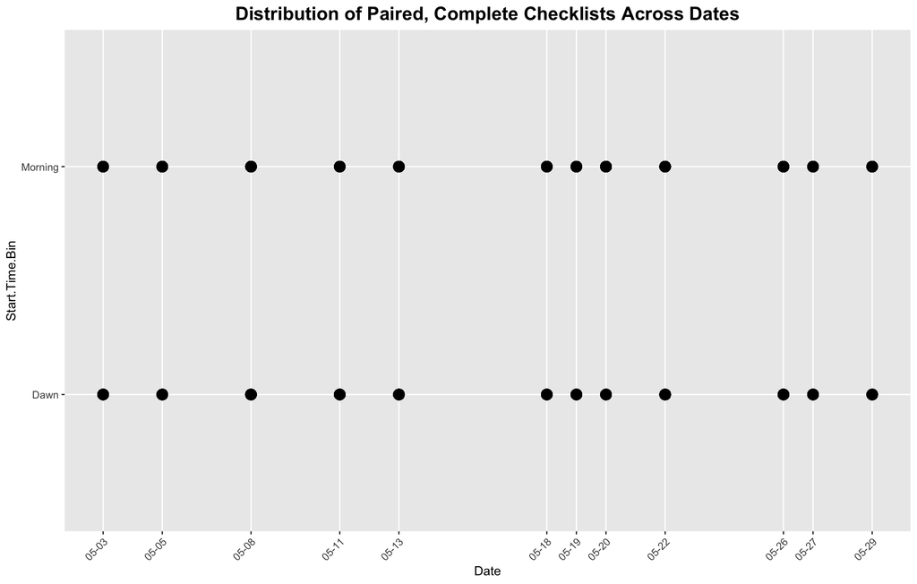

```r
# Graph representing the experiment dates
p_dates <- myebird_EXP %>%
  ggplot(aes(x=Date, y = Start.Time.Bin)) +
  geom_point(size = 4) +
  story_theme_sizes +
  theme(axis.text.x = element_text(angle=45, hjust=1),
          panel.grid.minor = element_blank()) +
  scale_x_date(breaks = sort(unique(myebird_EXP$Date)),
               date_labels = "%m-%d")+
  labs(title = "Distribution of Paired, Complete Checklists Across Dates")

p_dates
```

```r
ggsave(file.path(fig_dir, "Experiment Dates.png"),
             p_dates, width = canvas_wide$width, height = canvas_wide$height, dpi = 150)
```

### VI. A.2. Birdcast Migration

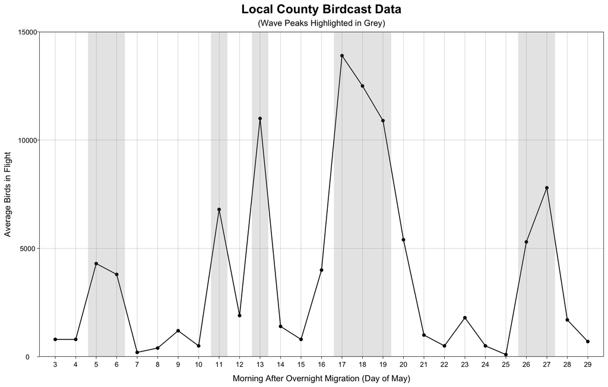

```r
# Line graph Avg Migration
p_birdcast <-
birdcast %>% filter(Day.of.May >=3 & Day.of.May <=29) %>%
                ggplot(aes(x=Day.of.May, y = Average.Birds.in.Flight))+
                geom_point() +
                geom_line()+
                band_peaks +
                theme_linedraw() + story_theme_sizes +
                labs(title = "Local County Birdcast Data",
                                    subtitle = "(Wave Peaks Highlighted in Grey)",
                                    x = "Morning After Overnight Migration (Day of May)",
                                    y = "Average Birds in Flight") +
                scale_x_continuous(breaks = seq(3,29,1),
                                    expand = expansion(mult = c(0.03,0.03)))+
# Scale for patchworking
                scale_y_continuous(limits = c(0,15000),
                                   breaks = seq(0,15000,5000),
                                   expand = expansion(mult= c(0,0)))+
                theme(axis.text.x = element_text(margin=margin(b=6, t=4), hjust = 0.5),
                      axis.text.y = element_text(margin = margin(l=5),hjust = 0.5),
                      panel.grid.minor = element_blank())

p_birdcast
```

```r
ggsave(file.path(fig_dir, "Radar-Measured Nightly Migration.png"),
             p_birdcast, width = canvas_wide$width, height = canvas_wide$height, dpi = 150)
```

## VI. B. All-Species Overview

A psuedolog transformation of the color scale is used, along with custom breaks, because a few species have very high counts

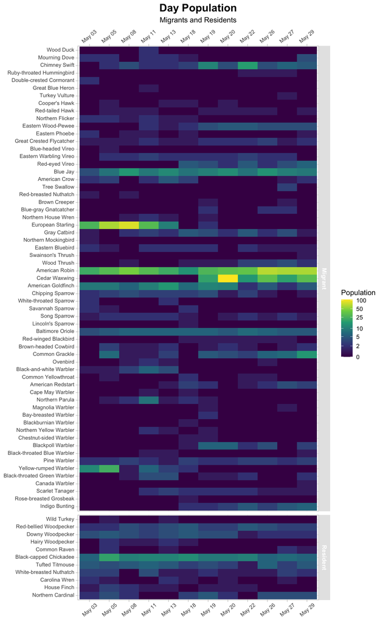

```r
# ALL Observations in Heat map, divided into Migrants and Residents
myebird_EXP_grouped <- myebird_EXP %>%
  left_join(my_tax_EXP %>% select(Species, Resident), by = "Species") %>%
  mutate(Resident = factor(Resident, levels = c(FALSE, TRUE), labels = c("Migrant", "Resident")))

p_heatmap_all <- myebird_EXP_grouped %>%
  ggplot(aes(x = Month.Day, y = Species, fill = Population)) +
  heatmap_theme +
  story_theme_sizes +
   labs(title = "Day Population",
       subtitle = "Migrants and Residents",
    #   x = "Date",
       y = NULL) +
  facet_grid(rows = vars(Resident), scales = "free_y", space = "free_y") +
  scale_fill_viridis_c(breaks = c(0,2,5,10,25,50,100), trans = "pseudo_log")+
 scale_x_discrete(sec.axis = dup_axis())+
  theme(axis.text.x.bottom = element_text(size=8, angle = 40, vjust = 0.6),
        axis.text.x.top = element_text(size=8, angle = 40, vjust = 0.4),
        axis.text.y = element_text(size = 8, vjust = 0.3))

p_heatmap_all
```

```r
ggsave(file.path(fig_dir, "Heatmap of All Species Observed.png"),
             p_heatmap_all, width = 11, height = 7, dpi = 150)
```

## VI. C. Favorite Migrants — In Depth

### VI. C.1. Heatmap

A psuedolog transformation of the color scale is used, along with custom breaks, because a few species have very high counts

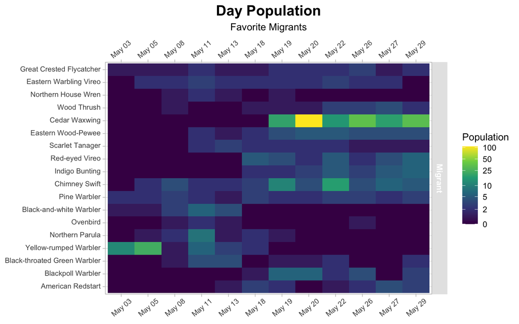

```r
# 18 FAVORITE MIGRANTS in Heat map -- keeps the "Migrant" facet strip used in
# the Overview heatmap (VI.B) so it's immediately clear these are all migrants.
good_patterns_grouped <- good_patterns %>%
  left_join(my_tax_EXP %>% select(Species, Resident), by = "Species") %>%
  mutate(Resident = factor(Resident, levels = c(FALSE, TRUE), labels = c("Migrant", "Resident")))

p_heatmap_favorites <- good_patterns_grouped %>%
  ggplot(aes(x = Month.Day, y = Species, fill = Population)) +
  heatmap_theme +
  story_theme_sizes +
  labs(title = "Day Population",
       subtitle = "Favorite Migrants",
       y = NULL) +
  facet_grid(rows = vars(Resident), scales = "free_y", space = "free_y") +
  scale_fill_viridis_c(breaks = c(0,2,5,10,25,50,100), trans = "pseudo_log")+
  scale_x_discrete(sec.axis = dup_axis())+
  theme(axis.text.x.bottom = element_text(size=8, angle = 40, vjust = 0.6),
        axis.text.x.top = element_text(size=8, angle = 40, vjust = 0.4),
        axis.text.y = element_text(size = 8, vjust = 0.3))

p_heatmap_favorites
```

```r
ggsave(file.path(fig_dir, "Heatmap of Favorite Migrants Observed.png"),
             p_heatmap_favorites, width = 8, height = 5, dpi = 150)
```

### VI. C.2. Ridges

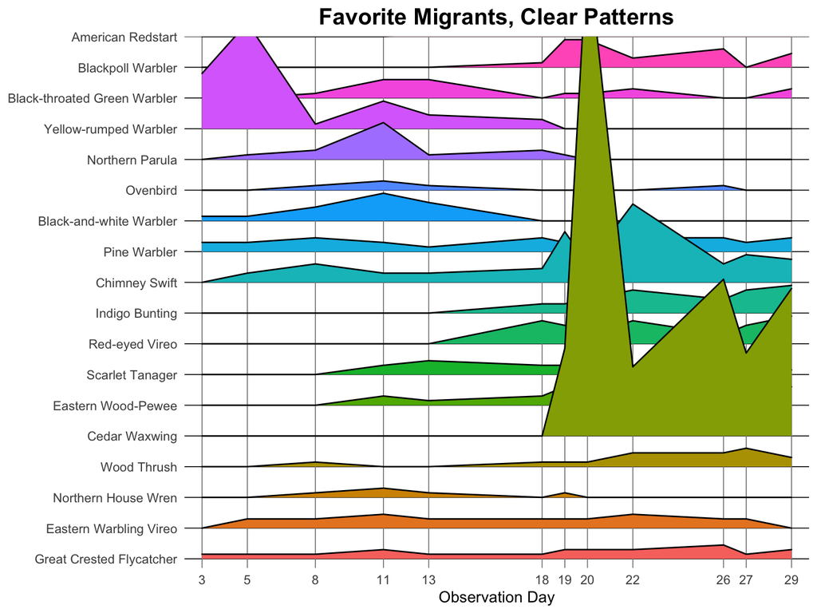

```r
# Make Ridges plot
p_good_patterns_ridges <- good_patterns %>%
                            ggplot(aes(x=Day, y = Species, height = Population, fill = Species))+
                            geom_ridgeline(scale = 0.15) +
                           # scale_fill_manual(values = warbler_colors) +
                           # band_peaks +
                            theme_minimal() + story_theme_sizes +
                            scale_x_continuous(breaks = obs_dates,
                                               expand = expansion(mult = c(0.03,0.03)),
                                               limits = c(3,29)) +
                            coord_cartesian(ylim = c(1.3, 17.4)) +
                            labs(title = "Favorite Migrants, Clear Patterns",
                                 #subtitle = "",
                                 y = NULL,
                                 x="Observation Day") +
                            theme(legend.position = "none",
                                  plot.title = element_text(hjust = 0.5),
                                  panel.grid.major.x = element_line(color = "gray50", linewidth = 0.3),
                                  panel.grid.major.y = element_line(color = "gray0", linewidth = 0.3),
                               #  axis.ticks.major.y = element_blank()) +  # not defined in element hierarcy error
                                #  axis.ticks.minor.x = element_blank(),  # not defined in element hierarcy error
                                  panel.grid.minor.x = element_blank())

# ---- TOGGLE: merge with the Birdcast panel above the ridges. Off by default
# (just ridges) -- flip to TRUE to bring the merge back rather than rebuilding
# it later. Uses the shared story_theme_sizes so the merged view reads at the
# same scale as every other plot in the doc. ----
show_birdcast_with_ridges <- FALSE

if (show_birdcast_with_ridges) {
  p_birdcast_large <-  p_birdcast +
    theme(
      axis.title.y = element_text(margin = margin(r = 0),vjust = 0.5),
      axis.text.y  = element_text(hjust = 1, margin = margin(r=3,l=0))
                                  )
  p_good_patterns_ridges_large <-
    p_good_patterns_ridges +
    theme(plot.title = element_text(margin = margin(t=5)))

  p_birdcast_large / p_good_patterns_ridges_large + plot_layout(heights = c(1,6))
} else {
  p_good_patterns_ridges
}
```

### VI. C.3. Observed Counts by Species

### VI. C.4. Observed vs Expected (real counts)

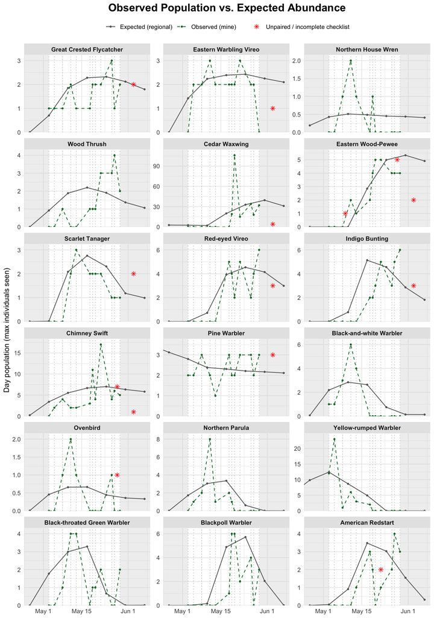

```r
# plot_observed_vs_expected() is defined once in section V.D -- see there
# for the full pipeline (rescaling, extra-checklist markers, background).
plot_observed_vs_expected(good_patterns_sp, "Observed Population vs. Expected Abundance",
                           site_file = "obsexp-favorites.png", width = 9, height = 12.8)
```

### VI. C.4a. Early-Arriving Breeders

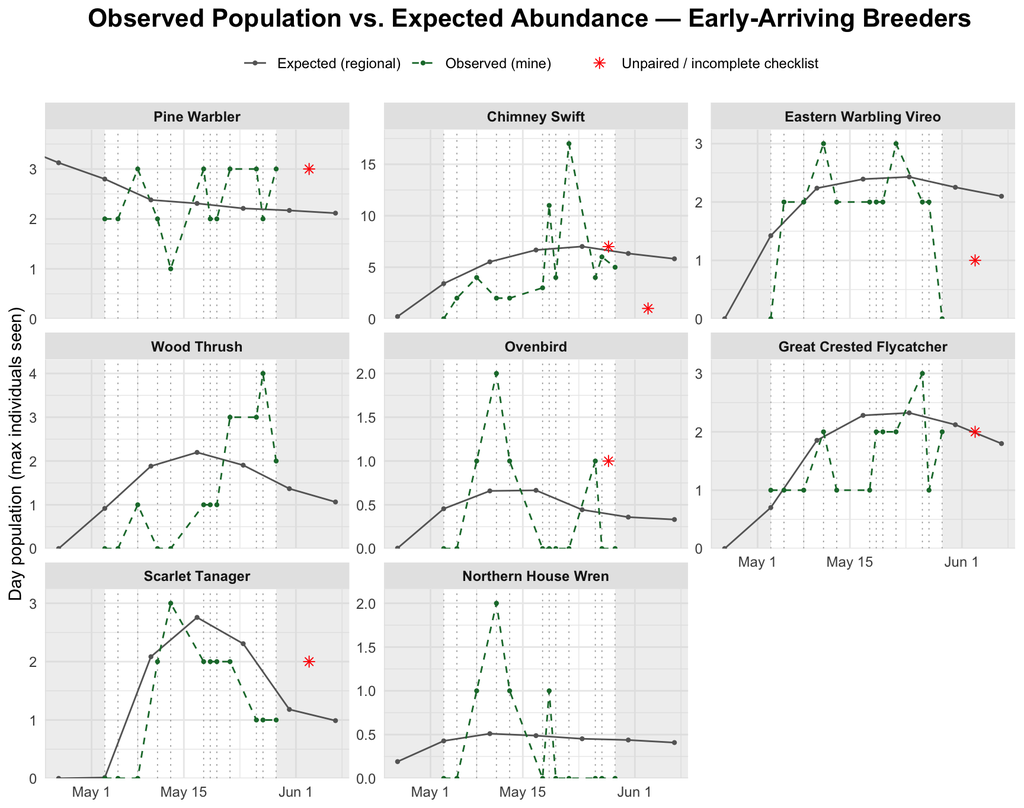

```r
plot_observed_vs_expected(
  intersect(early_breeding_sp, good_patterns_sp),
  "Observed Population vs. Expected Abundance — Early-Arriving Breeders",
  site_file = "obsexp-early-breeders.png", width = 9, height = 7.1
)
```

### VI. C.4b. Mid/Late-Arriving Breeders

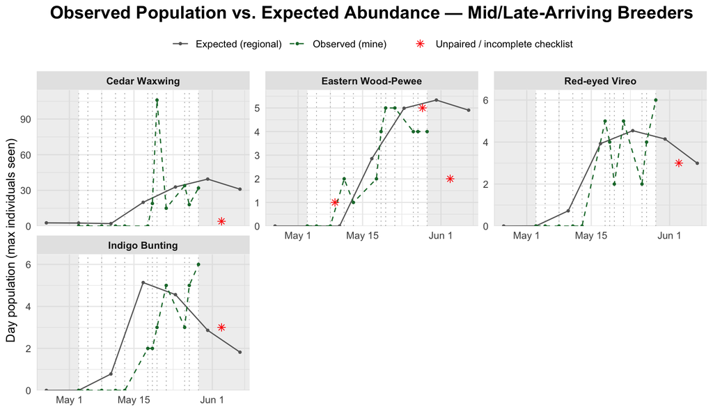

```r
plot_observed_vs_expected(
  intersect(midlate_breeding_sp, good_patterns_sp),
  "Observed Population vs. Expected Abundance — Mid/Late-Arriving Breeders",
  site_file = "obsexp-midlate-breeders.png", width = 9, height = 5.2
)
```

### VI. C.4c. Early Passing Migrants

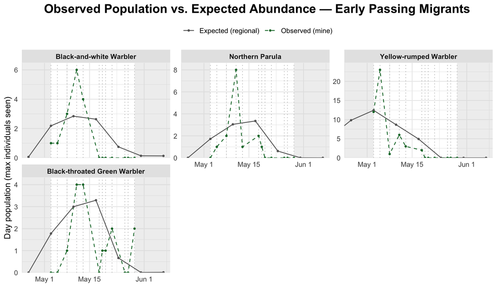

```r
plot_observed_vs_expected(
  intersect(early_passing_sp, good_patterns_sp),
  "Observed Population vs. Expected Abundance — Early Passing Migrants",
  site_file = "obsexp-early-passing.png", width = 9, height = 5.2
)
```

### VI. C.4d. Mid/Late Passing Migrants

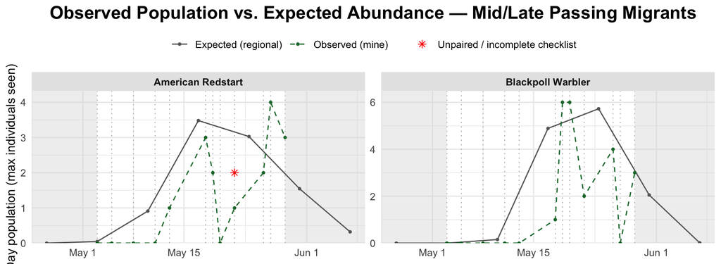

```r
plot_observed_vs_expected(
  intersect(midlate_passing_sp, good_patterns_sp),
  "Observed Population vs. Expected Abundance — Mid/Late Passing Migrants",
  site_file = "obsexp-midlate-passing.png", width = 9, height = 3.3
)
```

### VI. C.5. Single Species Multi-Panel Figures: EXPECTED, OBSERVED

## VI. D. Warblers — In Depth

### VI. D.1. Heatmap

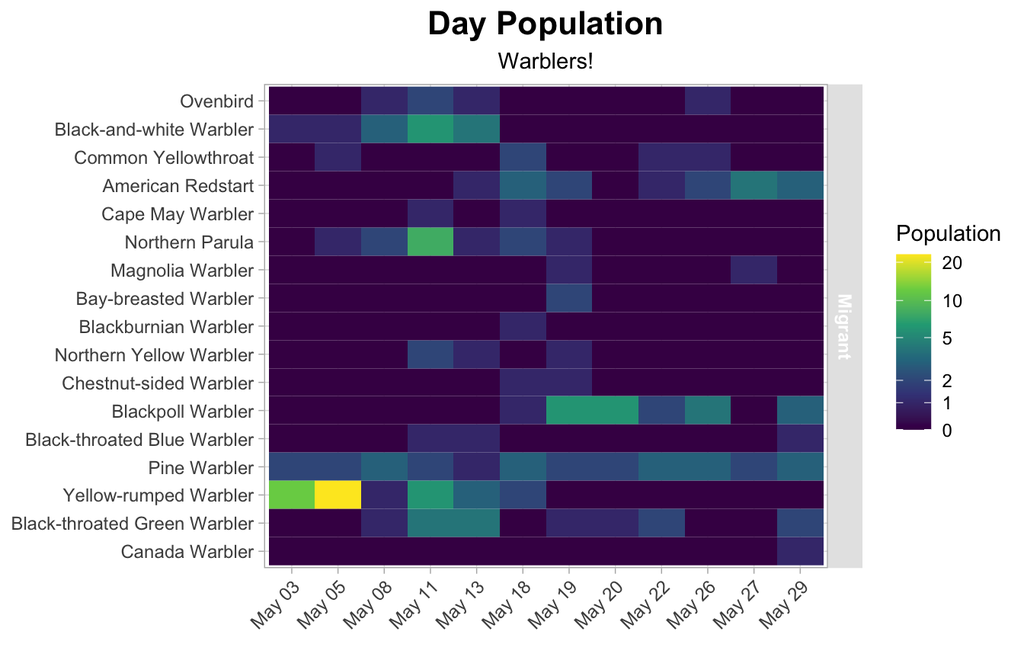

```r
# All Warblers -- keeps the "Migrant" facet strip used in the Overview
# heatmap (VI.B) and 18-Favorites heatmap (VI.C.1) for visual consistency.
warblers_grouped <- warblers %>%
  left_join(my_tax_EXP %>% select(Species, Resident), by = "Species") %>%
  mutate(Resident = factor(Resident, levels = c(FALSE, TRUE), labels = c("Migrant", "Resident")))

p_heatmap_warblers <- warblers_grouped %>%
ggplot(aes(x=Month.Day, y = Species, fill = Population))+
  heatmap_theme +
  story_theme_sizes +
  labs(title = "Day Population",
       subtitle = "Warblers!",
       x = "",
       y = NULL) +
  facet_grid(rows = vars(Resident), scales = "free_y", space = "free_y") +
  scale_fill_viridis_c(breaks = c(0,1, 2, 5,10,20),trans = "pseudo_log") +
  theme(axis.text.x = element_text(angle = 45, hjust = 1),
  axis.text.x.top = element_text(margin = margin(b=4), hjust = 0))

p_heatmap_warblers
```

```r
ggsave(file.path(fig_dir, "Heatmap of Warblers Observed.png"),
             p_heatmap_warblers, width = 11, height = 7, dpi = 150)
```

### VI. D.2. Ridges

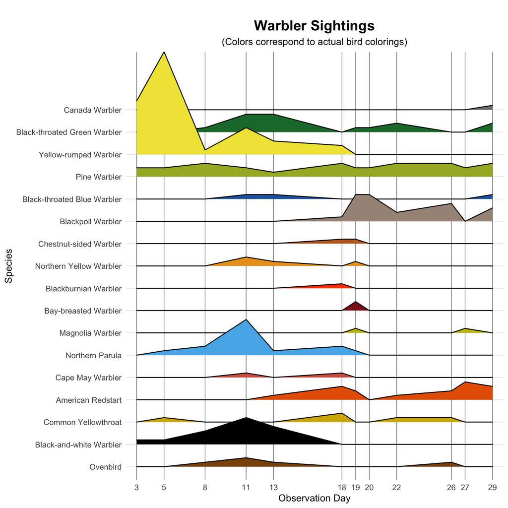

```r
# All warblers
p_warbs_ridges<- my_filter(warblers) %>%
                            ggplot(aes(x=Day, y = Species, height = Population, fill = Species))+
                            geom_ridgeline(scale = 0.2) +
                            scale_fill_manual(values = warbler_colors) +
                           # band_peaks +
                            theme_minimal() + story_theme_sizes +
                            scale_x_continuous(breaks = obs_dates,
                                               expand = expansion(mult = c(0.03,0.03)),
                                               limits = c(3,29)) +
                            labs(title = "\nWarbler Sightings",
                            subtitle = "(Colors correspond to actual bird colorings)",
                              x="Observation Day")+
                            theme(legend.position = "none",
                            plot.title = element_text(hjust = 0.5),
                            plot.subtitle = element_text(hjust = 0.5),
                                  panel.grid.major.x = element_line(color = "gray50", linewidth = 0.3),
                                  axis.ticks.minor.x = element_blank(),
                                  panel.grid.minor.x = element_blank(),
                                  axis.ticks.major.y = element_blank())

# ---- TOGGLE: merge with the Birdcast panel above the ridges (see VI.C.2
# for the same toggle on the favorites ridges). Off by default. ----
show_birdcast_with_ridges <- FALSE

if (show_birdcast_with_ridges) {
  p_birdcast / p_warbs_ridges + plot_layout(heights = c(1,6))
} else {
  p_warbs_ridges
}
```

### VI. D.3. Discrete Bar Graphs (technically more accurate than ridges)

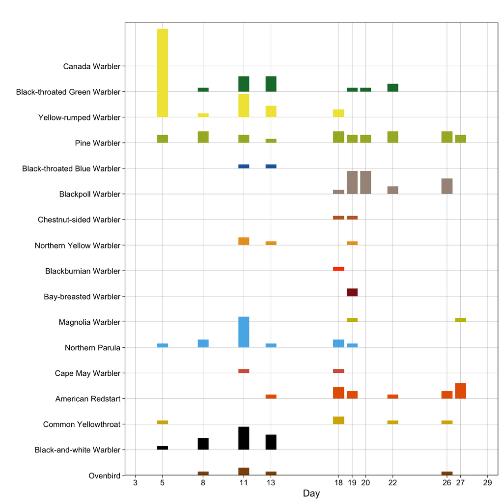

```r
# ALL WARBLERS

# STAGGERED BARS -- Use geom_rect so it can be merged like the ridgelines

# Give each species a numeric baseline position ####
warblers <- warblers %>%
    mutate(Species.Num = as.numeric(factor(Species)))

# GRAPHING
# Plot the Data ####
p_warbs_bars <- warblers %>%
    ggplot(aes(x = Day, y = Species.Num)) +
    geom_rect(aes(xmin = Day - 0.4, xmax = Day + 0.4,
                  ymin = Species.Num, ymax = Species.Num + Population * 0.15,
                  fill = Species)) +
# Theme and aesthetics ####
    theme_linedraw() + story_theme_sizes +
    scale_fill_manual(values = warbler_colors)+
    # band_peaks+   # grey wave-window bars hidden per request; drop the "#" to bring back
    labs(title = "",
         y = "")+
# Axes ####
    scale_x_continuous(
      limits = c(3,29),
      breaks = obs_dates,
      expand = expansion(mult= c(0.03,0.03))) +
    scale_y_continuous(
      breaks = sort(unique(warblers$Species.Num)),
      labels = levels(factor(warblers$Species)),
      expand = expansion(mult = c(0,0))) +
  # Use coord_cart instead of scale_y_cont(limits = ) so that geom_rect doesn't drop any bars if they go off the chart!
    coord_cartesian(ylim = c(1,18.7))+
    theme(legend.position = "none",
         # panel.grid.major = seq(1,31,7),
          panel.grid.minor = element_blank())

# ---- TOGGLE: merge with the Birdcast panel above the bars (see VI.C.2 for
# the same toggle on the favorites ridges). Off by default. ----
show_birdcast_with_bars <- FALSE

if (show_birdcast_with_bars) {
  p_birdcast / p_warbs_bars + plot_layout(heights= c(1,6))
} else {
  p_warbs_bars
}
```

### VI. D.4. Observed Counts by Species

### VI. D.5. Observed vs Expected (real counts)

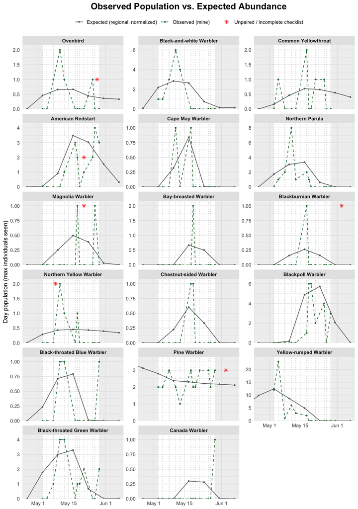

```r
# ---- 2-GRAPHS = ACTUAL OBSERVED COUNTS &  EBIRD EXPECTED ABUNDANCE ----
# ----- MANY SPECIES PER FIGURE
# ---- Only EXPECTED gets rescaled -- OBSERVED stays as real counts ----

exp_long <- expected_all %>%
  transmute(Species, yday, value = expected_abundance, source = "Expected (regional, normalized)") %>%
  mutate(Species = factor(Species, levels = warblers_sp))

obs_long <- myebird_EXP %>%
  filter(Species %in% warblers_sp) %>%
  mutate(yday = yday(Date)) %>%
  distinct(Species, yday, Population) %>%
  transmute(Species, yday, value = Population, source = "Observed (mine)") %>%
  mutate(Species = factor(Species, levels = warblers_sp))

exp_long <- trim_to_window(exp_long)
obs_long <- trim_to_window(obs_long)

# rescale_expected_to_observed() is defined once in section V.D -- see there
# for the full explanation. Observed itself is left completely untouched.
exp_scaled <- rescale_expected_to_observed(exp_long, obs_long)

combined <- bind_rows(exp_scaled, obs_long)

interp_obs <- function(sp, x) {
  o <- obs_long %>% filter(Species == sp) %>% arrange(yday)
  if (nrow(o) < 2) return(NA_real_)
  approx(o$yday, o$value, xout = x, rule = 1)$y
}

extra_counts <- myebird_EXP_extra_obs %>%
  filter(Presence.Only == FALSE) %>%
  filter(Species %in% warblers_sp) %>%
  mutate(Species = factor(Species, levels = warblers_sp),
         yday = yday(Date)) %>%
  rowwise() %>%
  mutate(obs_interp = interp_obs(Species, yday)) %>%
  ungroup() %>%
  filter(is.na(obs_interp) | Count > obs_interp) %>%
  trim_to_window()

ggplot(combined, aes(x = yday, y = value, color = source, linetype = source)) +
  align_layers(default_range) +                   # grey out beyond your dates + dotted line per observation day
                                                    # (same background style as the multi-panel figures, VI.D.6)
                                                    # -- also supplies the x scale and xlim, so no separate
                                                    # scale_x_continuous()/coord_cartesian() needed below
  geom_line(linewidth = 0.5) +
  geom_point(size = 0.8) +
  geom_point(data = extra_counts,
             aes(x = yday, y = Count, shape = "Unpaired / incomplete checklist"),
             color = "red", size = 2, inherit.aes = FALSE) +

  # all three scales share name = NULL, which merges color + linetype into ONE legend
  scale_color_manual(name = NULL,
    values = c("Expected (regional, normalized)" = "grey40", "Observed (mine)" = "#1B7837")) +
  scale_linetype_manual(name = NULL,
    values = c("Expected (regional, normalized)" = "solid", "Observed (mine)" = "dashed")) +
  scale_shape_manual(name = NULL,
    values = c("Unpaired / incomplete checklist" = 8)) +
  # legend key would otherwise be black, since color is set outside aes()
  guides(shape = guide_legend(override.aes = list(color = "red"))) +

  facet_wrap(~Species, ncol = 3, scales = "free_y") +
  expand_limits(y = 0) +                          # every panel's y-axis starts at 0, even with free scales
  scale_y_continuous(expand = expansion(mult = c(0, 0.08))) +  # 0 stays pinned at the axis floor; 8% breathing room above the highest point

  labs(title = "Observed Population vs. Expected Abundance",
       x = NULL, y = "Day population (max individuals seen)", shape = NULL) +

  theme_minimal() + story_theme_sizes +
  theme(legend.position = "top",
        panel.spacing.y = unit(0.6, "lines"),                            # more gap between rows than within
        panel.spacing.x = unit(0.3, "lines"))
```

### VI. D.5a. Early-Arriving Breeders

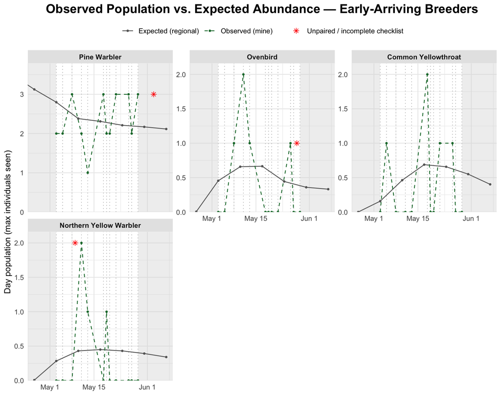

```r
plot_observed_vs_expected(
  intersect(early_breeding_sp, warblers_sp),
  "Observed Population vs. Expected Abundance — Early-Arriving Breeders",
  site_file = "obsexp-warblers-early-breeders.png", width = 9, height = 7.1
)
```

### VI. D.5b. Mid/Late-Arriving Breeders

```r
# intersect(midlate_breeding_sp, warblers_sp) is empty -- none of my 17
# warblers fall in this group, so there's no plot to make. Left as eval =
# FALSE (not deleted) so the chunk still documents why this pairing is
# skipped, mirroring VI.C.4a-d/VI.D.5a-d 1:1.
plot_observed_vs_expected(
  intersect(midlate_breeding_sp, warblers_sp),
  "Observed Population vs. Expected Abundance — Mid/Late-Arriving Breeders"
)
```

### VI. D.5c. Early Passing Migrants, VI. D.5d. Mid/Late Passing Migrants

`intersect(early_passing_sp, warblers_sp)` and `intersect(midlate_passing_sp, warblers_sp)` are both the full early/midlate passing groups – every species in those two groups is already a warbler. So these are identical to VI.C.4c/VI.C.4d and aren’t replotted here; reuse those figures (`obsexp-early-passing.png` / `obsexp-midlate-passing.png`) directly on the warblers page.

### VI. D.6. Single Species Multi-Panel Figures: EXPECTED, OBSERVED

## VI. E. Wave Breakdowns

### VI. E.1. Species Richness

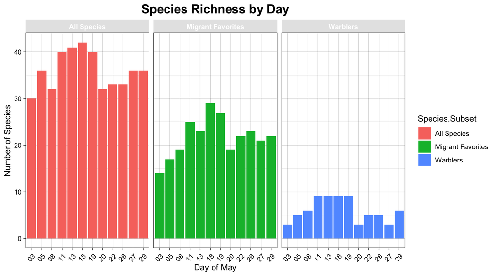

```r
subset_labels <-c(
  "Tot.Sp"              =   "All Species",
  "Tot.Sp.Faves"        = "Favorite Species",
  "Tot.Sp.Nonres.Faves" = "Migrant Favorites",
  "Tot.Sp.Warblers"     = "Warblers"
)


richness_long %>% filter(!Species.Subset %in% c("Tot.Sp.Faves"))%>%
ggplot(aes(x=Month.Day, y = Total.Species, fill = Species.Subset))+
  geom_col() +
  facet_wrap(~Species.Subset, labeller = as_labeller(subset_labels)) +
  scale_fill_discrete(labels = subset_labels) +
  scale_x_discrete(labels = function(x) sub("^[A-Za-z]+ ", "", x)) +
  theme_linedraw() + story_theme_sizes +
  theme(axis.text.x = element_text(angle = 45, vjust = 0.4)) +
  labs(title = "Species Richness by Day",
       y = "Number of Species",
       x = "Day of May")
```

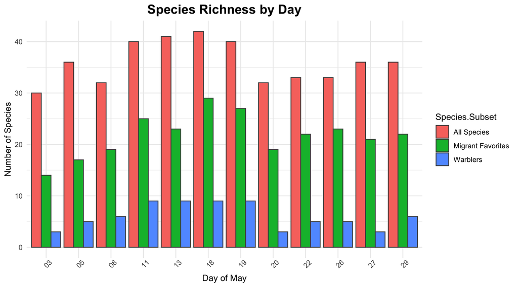

```r
richness_long %>% filter(!Species.Subset %in% c("Tot.Sp.Faves"))%>%
ggplot(aes(x=Month.Day, y = Total.Species, fill = Species.Subset))+
  geom_col(position = "dodge", color = "grey30") +
  scale_fill_discrete(labels = subset_labels)+
  scale_x_discrete(labels = function(x) sub("^[A-Za-z]+ ", "", x)) +
  theme_minimal() + story_theme_sizes +
  labs(title = "Species Richness by Day",
       y = "Number of Species",
       x = "Day of May") +
  theme(axis.text.x = element_text(angle = 45, vjust = 1))
```

### VI. E.2. Style A: Birdcast + Wave-by-Wave Species Bars (Original)

```r
# ---- 1. WAVE-HIGHLIGHTABLE BAND PEAKS ----
# wave_bounds (one row per wave) was already defined in section V.C and
# is reused here as the single source of truth for every wave's bounds.

make_band_peaks <- function(highlight_wave = NULL) {
  pmap(wave_bounds, function(Wave, xmin, xmax) {
    if (!is.null(highlight_wave) && Wave == highlight_wave) {
      annotate("rect", xmin = xmin, xmax = xmax, ymin = -Inf, ymax = Inf,
               fill = "#F5A623", alpha = 0.35, color = "#B8730A", linewidth = 1)
    } else {
      annotate("rect", xmin = xmin, xmax = xmax, ymin = -Inf, ymax = Inf,
               fill = "grey50", alpha = 0.2)
    }
  })
}

# "Wave N" text sitting inside the top of each band, as in the slides
make_band_labels <- function(y = 13600, size = 2.7) {
  annotate("text",
           x = (wave_bounds$xmin + wave_bounds$xmax) / 2,
           y = y, label = wave_bounds$Wave,
           size = size, color = "grey20")
}

# ---- 2. BIRDCAST PLOT BUILDER ----
build_birdcast_plot <- function(bands = band_peaks, current_day = NULL, previous_day = NULL) {
  p <- birdcast %>% filter(Day.of.May >= 3 & Day.of.May <= 29) %>%
    ggplot(aes(x = Day.of.May, y = Average.Birds.in.Flight)) +
    bands +                     # bands behind the trace
    make_band_labels() +
    geom_point() +
    geom_line() +
    theme_linedraw() +
    labs(title = "Local County Birdcast Data",
         x = "Morning After Overnight Migration (Day of May)",
         y = "Average Birds in Flight") +
    scale_x_continuous(breaks = seq(3, 29, 1), expand = expansion(mult = c(0.03, 0.03))) +
    scale_y_continuous(limits = c(0, 15000), breaks = seq(0, 15000, 5000), expand = expansion(mult = c(0, 0))) +
    theme(plot.title = element_text(hjust = 0.5, size = title_size),
          plot.subtitle = element_text(hjust = 0.5, size = subtitle_size),
          axis.title.x = element_text(size = axis_title_size),
          axis.text.x = element_text(size = axis_text_size, margin = margin(b = 6, t = 4), hjust = 0.5),
          axis.title.y = element_text(size = axis_title_size),
          axis.text.y = element_text(size = axis_text_size, margin = margin(l = 5), hjust = 0.5),
          panel.grid.minor = element_blank())

  # today's survey day: solid dark line. The day it's being compared
  # against (previous_obs_day(), below): lighter, dashed -- drawn first so
  # today's solid line sits on top if they're ever close together.
  if (!is.null(previous_day)) {
    p <- p + geom_vline(xintercept = previous_day, color = "grey55", linewidth = 0.6, linetype = "dashed")
  }
  if (!is.null(current_day)) {
    p <- p + geom_vline(xintercept = current_day, color = "grey15", linewidth = 0.8, linetype = "solid")
  }
  p
}

# ---- 2b. PREVIOUS SURVEY DAY (whatever Delta was actually computed against) ----
previous_obs_day <- function(day) {
  all_days <- sort(unique(myebird_EXP$Day))
  prior <- all_days[all_days < day]
  if (length(prior) == 0) return(NA_integer_)
  max(prior)
}

# ---- 3. WAVE ASSIGNMENT FOR YOUR OBSERVATION DAYS ----
assign_wave <- function(day) {
  case_when(
    day %in% c(5, 6)       ~ "Wave 1",
    day == 11              ~ "Wave 2",
    day == 13              ~ "Wave 3",
    day %in% c(17, 18, 19) ~ "Wave 4",
    day %in% c(26, 27)     ~ "Wave 5",
    TRUE                   ~ NA_character_
  )
}

# ---- 4. SPECIES x DAY GRID WITH DELTA ----
build_species_day_grid <- function(species_subset) {
  all_dates <- sort(unique(myebird_EXP$Date))
  myebird_EXP %>%
    select(Date, Species, Population) %>%
    distinct() %>%
    filter(Species %in% species_subset) %>%
    mutate(Species = as.character(Species)) %>%
    complete(Date = all_dates, Species = species_subset, fill = list(Population = 0)) %>%
    mutate(Species = factor(Species, levels = species_subset),
           Day = day(Date)) %>%
    arrange(Species, Date) %>%
    group_by(Species) %>%
    mutate(Delta = Population - lag(Population)) %>%
    ungroup()
}

# ---- 5. TAG GRID WITH WAVE ----
tag_wave_days <- function(grid_df) {
  grid_df %>%
    mutate(Wave = factor(assign_wave(Day), levels = wave_bounds$Wave)) %>%
    filter(!is.na(Wave)) %>%
    mutate(Wave = droplevels(Wave))
}

# ---- 6. WHICH OBSERVED DAYS FALL IN A GIVEN WAVE ----
obs_days_for_wave <- function(wave_name) {
  all_days <- sort(unique(myebird_EXP$Day))
  all_days[assign_wave(all_days) %in% wave_name]
}

# ---- 7. UNCOMMON SPECIES (< 4 total individuals across the whole experiment) ----
uncommon_sp <- myebird_EXP %>%
  select(Date, Species, Population) %>%
  distinct() %>%
  group_by(Species) %>%
  summarize(Total.Population = sum(Population), .groups = "drop") %>%
  filter(Total.Population < 4) %>%
  pull(Species) %>%
  as.character()

# ---- 8. FIXED AXIS FOR ALL WAVE-DELTA GRAPHS ----
# Same frame on every graph so waves stay comparable. Bars past the frame are
# CLAMPED to the frame edge (see y_draw below) and their label still prints the
# true count, so a handful of blown-out bars never force the axis to expand.
delta_ylim   <- c(-6, 11)                 # visible frame
delta_breaks <- c(-5, 0, 5, 10)           # axis ticks

# same idea, for the companion absolute-count graph (VI.E.2, item 10b) --
# counts are never negative, so the frame starts at 0 instead of -6
count_ylim   <- c(0, 20)                  # visible frame -- bars past this are clamped to the frame
                                           # edge, with the true count shown in parentheses (see
                                           # label_text in plot_day_count below)
count_breaks <- c(0, 5, 10, 15, 20)  # axis ticks

# ---- 9. SPECIES SUBSET: FAVORITES MINUS RESIDENTS ----
# favorites_nonresident_sp was already computed in section II.D.1 (it's also
# used by the richness calculation above) -- reused here as-is.
grid_favorites_nonresident <- build_species_day_grid(favorites_nonresident_sp)
grid_favorites_nonresident_wave <- tag_wave_days(grid_favorites_nonresident)
warbler_sp_in_favorites_nonresident <- intersect(favorites_nonresident_sp, warblers_sp)
```

```r
# ---- 10. ONE DAY'S BARS ----
plot_day_delta <- function(df_wave, wave_name, day, subset_label, warbler_sp = NULL) {
  df <- df_wave %>%
    filter(Wave == wave_name, Day == day, !is.na(Delta), Delta != 0) %>%
    mutate(Species = droplevels(Species))

  lab_off  <- 0.55   # in-range label sits this far past the bar tip
  cap_off  <- 1.30   # capped label sits this far INSIDE the frame edge,
                     # which also keeps it clear of the "Warblers" label below

  df <- df %>%
    mutate(
      # y_draw is what geom_col actually draws.  clip = "off" is needed for the
      # "Warblers" bracket label, and it also stops ggplot from trimming the
      # bars, so an out-of-range bar has to be clamped in the DATA or it runs
      # straight off the bottom of the figure.
      y_draw  = pmin(pmax(Delta, delta_ylim[1]), delta_ylim[2]),
      # ">=" so a bar that lands exactly on the frame edge is labelled inside
      # the bar too, the way the slides do it
      Capped  = Delta >= delta_ylim[2] | Delta <= delta_ylim[1],
      # in-range bar: label just past the tip, in black.
      # capped bar: label tucked inside the bar in white, so it can never
      # collide with the title above or the species names below.
      label_y    = ifelse(Capped, y_draw - sign(Delta) * cap_off,
                                  y_draw + sign(Delta) * lab_off),
      label_col  = ifelse(Capped, "white", "black"),
      label_text = ifelse(Delta > 0, paste0("+", Delta), as.character(Delta))
    )

  p <- ggplot(df, aes(x = Species, y = y_draw, fill = Delta > 0)) +
    geom_col(width = 0.65) +
    geom_hline(yintercept = 0, color = "grey40", linewidth = 0.3) +
    geom_text(aes(y = label_y, label = label_text, color = label_col),
              size = 2.9, fontface = "bold", show.legend = FALSE) +
    scale_color_identity() +
    scale_fill_manual(values = c(`TRUE` = "#2166AC", `FALSE` = "#B2182B"), guide = "none") +
    scale_y_continuous(breaks = delta_breaks, expand = expansion(mult = c(0, 0))) +
    coord_cartesian(ylim = delta_ylim, clip = "off") +
    labs(title = "Change vs. Previous Day",
         x = NULL, y = "Change") +
    theme_minimal() +
    theme(plot.title   = element_text(hjust = 0.5, face = "bold", size = 12,
                                      margin = margin(b = 14)),  # room for capped labels above the frame
          plot.margin  = margin(t = 8, r = 12, b = 8, l = 8),
          axis.text.x  = element_text(angle = 45, hjust = 1, size = 7.5,
                                      margin = margin(t = 4)),
          panel.grid.minor = element_blank())

  # green bracket + label around the warbler block
  if (!is.null(warbler_sp) && length(warbler_sp) > 0) {
    warb_present <- intersect(levels(df$Species), warbler_sp)
    if (length(warb_present) > 0) {
      xs <- match(warb_present, levels(df$Species))
      x_min <- min(xs) - 0.5; x_max <- max(xs) + 0.5
      p <- p +
        annotate("rect", xmin = x_min, xmax = x_max,
                 ymin = delta_ylim[1], ymax = delta_ylim[2],
                 fill = NA, color = "#1B7837", linewidth = 0.7) +
        # label sits just INSIDE the frame, so it can't collide with the
        # species names below; the white fill keeps it readable if a bar
        # happens to run behind it
        annotate("label", x = (x_min + x_max) / 2, y = delta_ylim[1] + 0.42,
                 label = "Warblers", color = "#1B7837", fontface = "bold", size = 3.2,
                 fill = "white", linewidth = 0, label.padding = unit(0.12, "lines"))
    }
  }
  p
}

# ---- 10b. ONE DAY'S ABSOLUTE COUNTS (companion to plot_day_delta) ----
# Same Wave/Day/Species selection as plot_day_delta() (species with a
# nonzero Delta that day) -- same x-axis order and count, so the two bar
# charts read as a matched pair: this one answers "how many, actually?"
# for a species whose Delta alone ("-1") doesn't say whether that was
# 3->2 or 1->0. Diamond markers (uncommon species) live here now, not on
# the Delta graph.
plot_day_count <- function(df_wave, wave_name, day, subset_label, warbler_sp = NULL) {
  df <- df_wave %>%
    filter(Wave == wave_name, Day == day, !is.na(Delta), Delta != 0) %>%
    mutate(Species = droplevels(Species),
           Is.Uncommon = Species %in% uncommon_sp)

  lab_off  <- 0.55
  cap_off  <- 1.30
  diam_off <- 1.7

  df <- df %>%
    mutate(
      y_draw     = pmin(Population, count_ylim[2]),   # counts are never negative, so only the top needs clamping
      Capped     = Population >= count_ylim[2],
      label_y    = ifelse(Capped, y_draw - cap_off, y_draw + lab_off),
      label_col  = ifelse(Capped, "white", "black"),
      # capped bars show their true count in parentheses, since the bar
      # itself no longer reaches that height on the (now shorter) axis
      label_text = ifelse(Capped, paste0("(", Population, ")"), as.character(Population)),
      diamond_y  = ifelse(Capped, y_draw - (cap_off + 1.1), y_draw + diam_off)
    )

  p <- ggplot(df, aes(x = Species, y = y_draw)) +
    geom_col(width = 0.65, fill = "#1B7837") +
    geom_text(aes(y = label_y, label = label_text, color = label_col),
              size = 2.9, fontface = "bold", show.legend = FALSE) +
    scale_color_identity() +
    scale_y_continuous(breaks = count_breaks, expand = expansion(mult = c(0, 0))) +
    coord_cartesian(ylim = count_ylim, clip = "off") +
    labs(title = "Observed Population",
         x = NULL, y = "Population") +
    theme_minimal() +
    theme(plot.title   = element_text(hjust = 0.5, face = "bold", size = 12,
                                      margin = margin(b = 14)),
          plot.margin  = margin(t = 8, r = 12, b = 8, l = 8),
          axis.text.x  = element_text(angle = 45, hjust = 1, size = 7.5,
                                      margin = margin(t = 4)),
          panel.grid.minor = element_blank())

  # diamond on every uncommon-species bar -- ONLY when actually seen that day
  # (Population > 0). Without this, a species dropping TO 0 (a real Delta,
  # so it's still in df) got a diamond despite not being seen.
  diamonds <- df %>% filter(Is.Uncommon, Population > 0)
  if (nrow(diamonds) > 0) {
    p <- p + geom_point(data = diamonds, aes(x = Species, y = diamond_y),
                        shape = 18, size = 3.4, color = "#F5A623", inherit.aes = FALSE)
  }
```

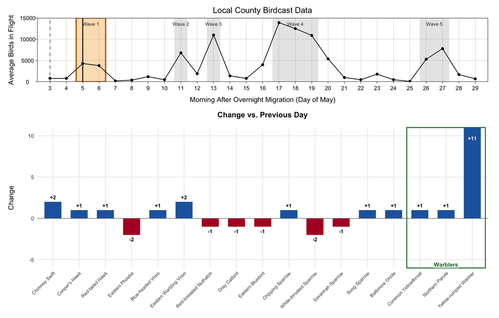

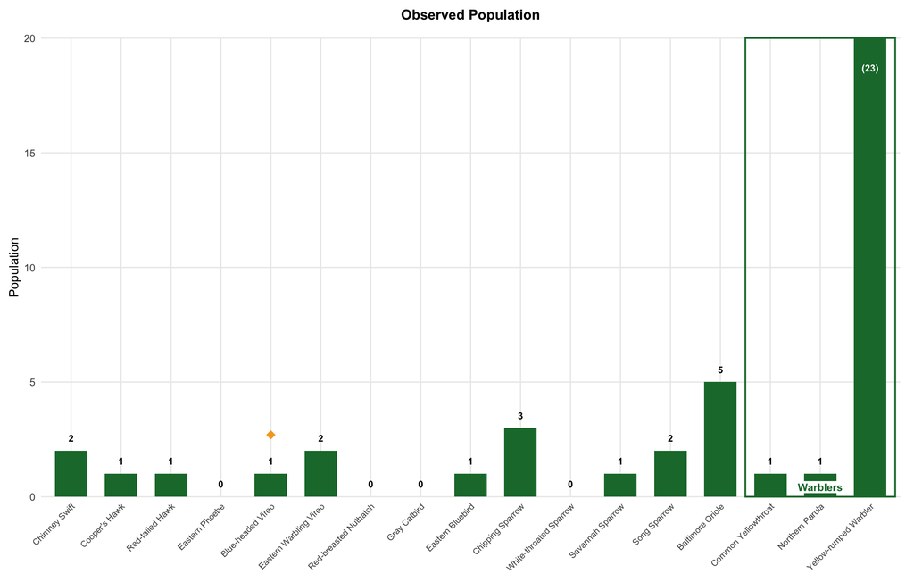

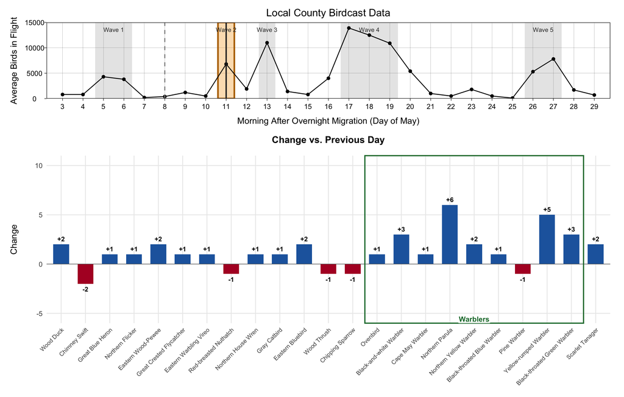

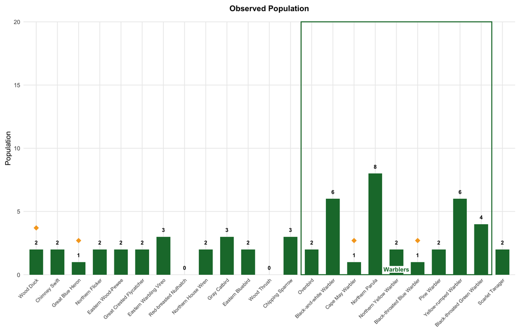

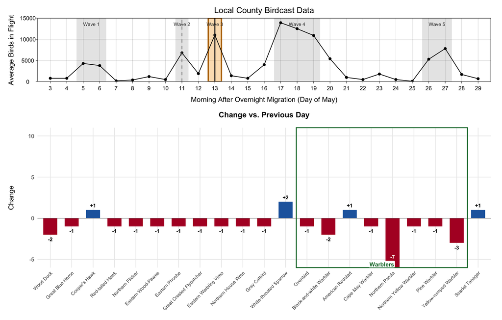

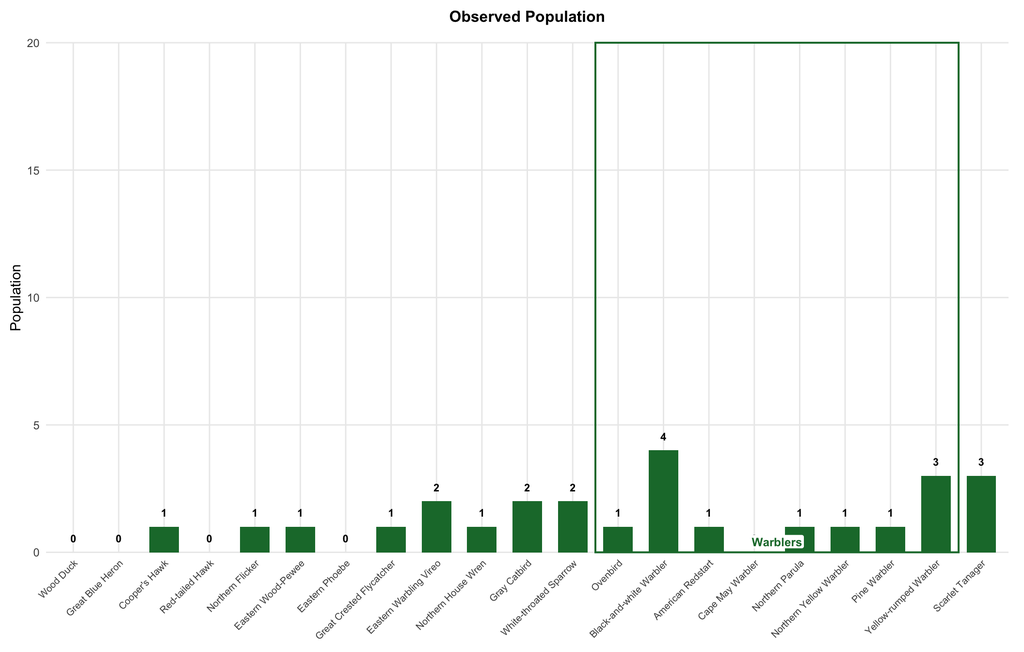

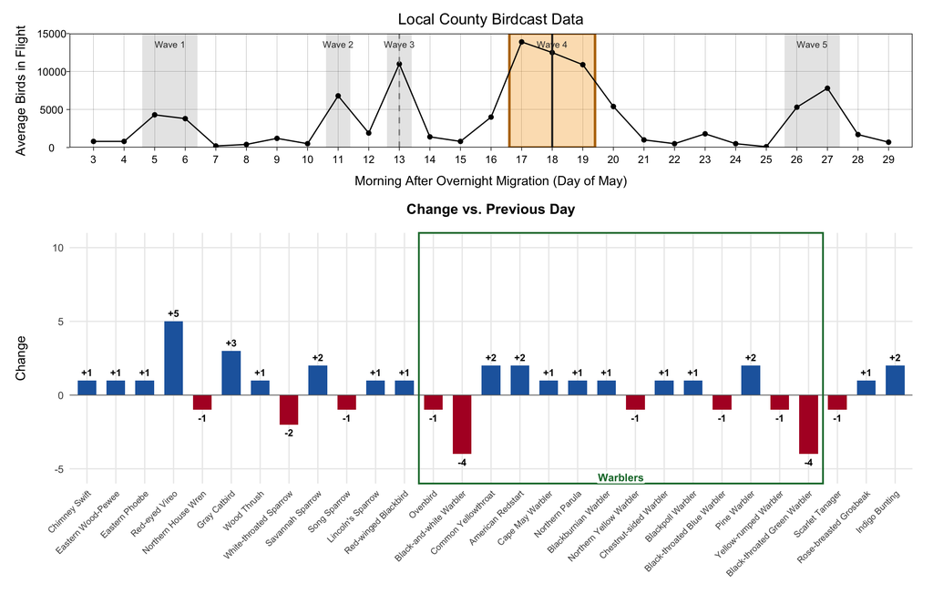

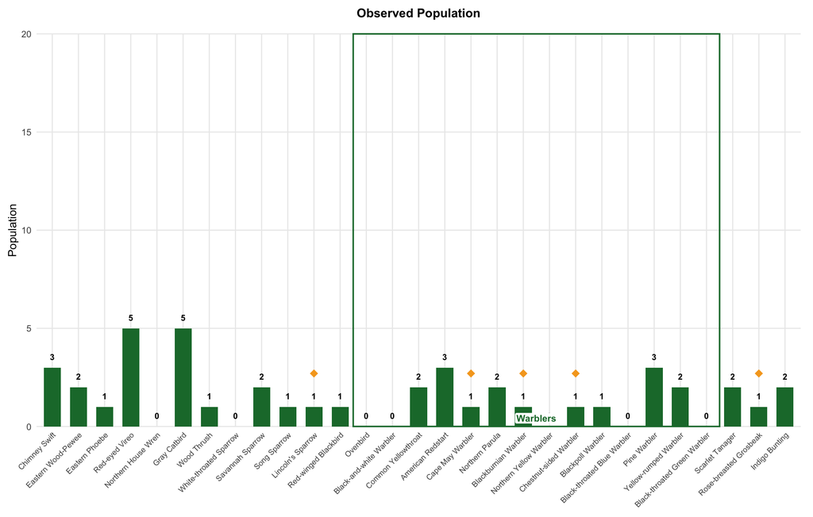

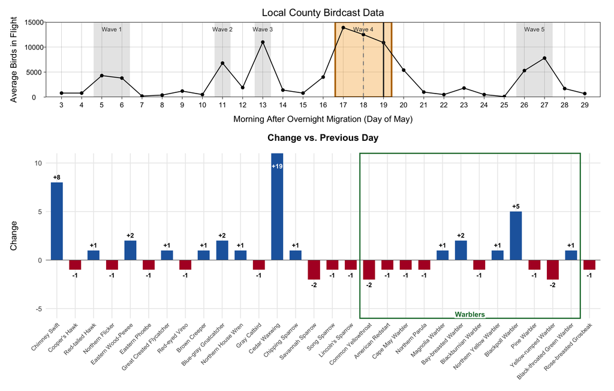

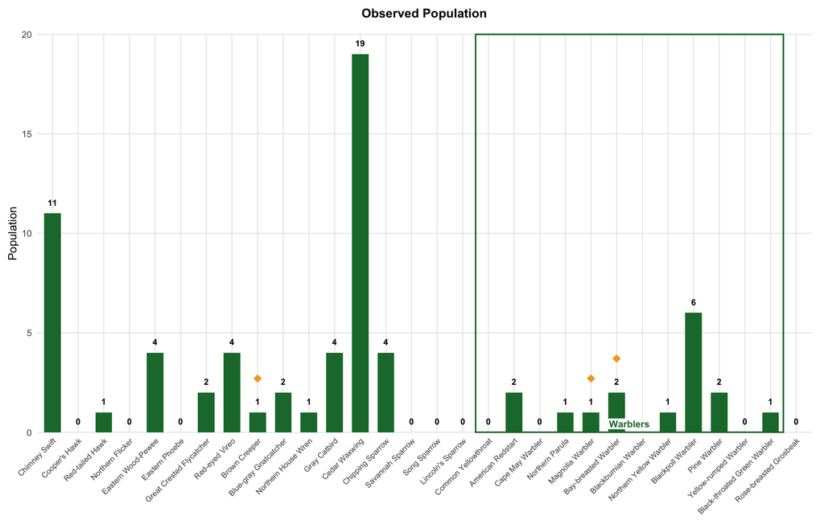

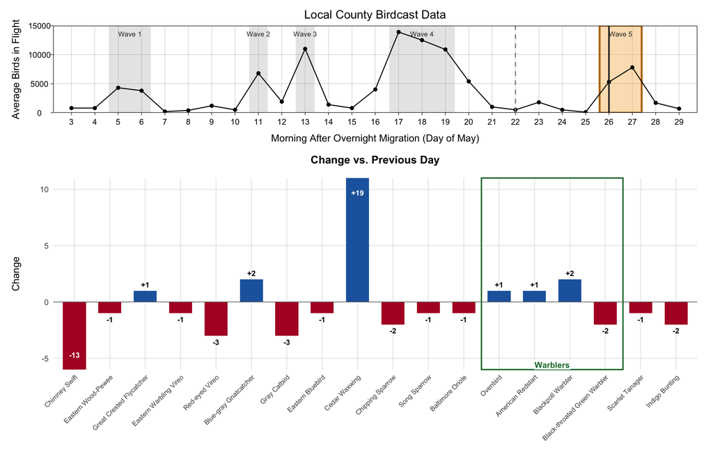

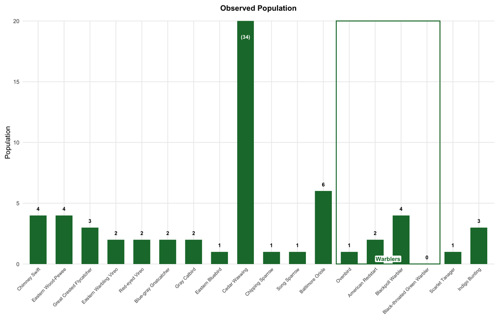

[2 more figures not shown]

```r
  # green bracket + label around the warbler block (same as plot_day_delta)
  if (!is.null(warbler_sp) && length(warbler_sp) > 0) {
    warb_present <- intersect(levels(df$Species), warbler_sp)
    if (length(warb_present) > 0) {
      xs <- match(warb_present, levels(df$Species))
      x_min <- min(xs) - 0.5; x_max <- max(xs) + 0.5
      p <- p +
        annotate("rect", xmin = x_min, xmax = x_max,
                 ymin = count_ylim[1], ymax = count_ylim[2],
                 fill = NA, color = "#1B7837", linewidth = 0.7) +
        annotate("label", x = (x_min + x_max) / 2, y = count_ylim[1] + 0.42,
                 label = "Warblers", color = "#1B7837", fontface = "bold", size = 3.2,
                 fill = "white", linewidth = 0, label.padding = unit(0.12, "lines"))
    }
  }
  p
}

# ---- 11. BIRDCAST PANEL ABOVE THAT DAY'S DELTA BARS ----
plot_day_with_birdcast <- function(df_wave, wave_name, day, subset_label, warbler_sp = NULL) {
  p_top <- build_birdcast_plot(make_band_peaks(highlight_wave = wave_name),
                                current_day = day, previous_day = previous_obs_day(day)) +
    theme(plot.title = element_text(size = 13), plot.subtitle = element_text(size = 9))
  p_bottom <- plot_day_delta(df_wave, wave_name, day, subset_label, warbler_sp = warbler_sp)
  p_top / p_bottom + plot_layout(heights = c(1, 2.2))
}

# ---- 12. OUTPUT: ALL WAVES ----
# fig.width / fig.height live in THIS chunk header, so every wave gets the same
# frame. Keep the whole loop in one chunk; splitting it (or dropping the header
# options on one chunk) is what made the last wave render at a different size.
#
# RStudio's inline preview re-renders the most recently drawn plot at whatever
# size the pane happens to be, so the last graph in a loop can still LOOK
# smaller there. The files written below are the ones to trust, and they are
# what the portfolio page should use.
save_wave_figs <- TRUE
fig_dir        <- "figures/waves"
if (save_wave_figs) dir.create(fig_dir, recursive = TRUE, showWarnings = FALSE)

for (wave_name in wave_bounds$Wave) {
  for (d in obs_days_for_wave(wave_name)) {
    p <- plot_day_with_birdcast(grid_favorites_nonresident_wave, wave_name, d,
                                "Non-Resident Favorites",
                                warbler_sp = warbler_sp_in_favorites_nonresident)
    print(p)

    # companion count graph -- same species/order/width as the Delta graph
    # above (same df_wave/wave_name/day/warbler_sp), printed directly below
    # it so the two read as a matched pair. Printed at the full figure
    # height (no blank spacer). count_ylim caps at 20; any bar past that
    # is clamped with its true count shown in parentheses (see
    # plot_day_count's label_text) rather than stretching the axis.
    p_count <- plot_day_count(grid_favorites_nonresident_wave, wave_name, d,
                              "Non-Resident Favorites",
                              warbler_sp = warbler_sp_in_favorites_nonresident)
    print(p_count)

    if (save_wave_figs) {
      ggsave(file.path(fig_dir, sprintf("%s_day%02d.png", gsub(" ", "", wave_name), d)),
             p, width = canvas_wide$width, height = canvas_wide$height, dpi = 150)
      ggsave(file.path(fig_dir, sprintf("%s_day%02d_counts.png", gsub(" ", "", wave_name), d)),
             p_count, width = canvas_wide$width, height = canvas_wide$height, dpi = 150)
      # birdcast panel alone (no bottom "Change vs. Previous Day" chart) --
      # this is the one the story site uses now that Style C covers the
      # per-species breakdown on its own. Sized on its own terms (not the
      # 1:2.2 squeeze plot_day_with_birdcast uses to fit above the delta
      # bars) since it's no longer sharing a figure with anything else.
      ggsave(file.path(fig_dir, sprintf("%s_day%02d_birdcast.png", gsub(" ", "", wave_name), d)),
             build_birdcast_plot(make_band_peaks(highlight_wave = wave_name),
                                  current_day = d, previous_day = previous_obs_day(d)),
             width = canvas_wide$width, height = 4.5, dpi = 150)
    }
  }
}
```

## VI. E.3. Alternate Wave-Bar Visualizations (Experimental)

```r
# Taxonomy grouping, shared by Styles B and D
taxon_groups <- read.csv("./data/Taxonomy-ish_Groupings/species_groups_moderate.csv", stringsAsFactors = FALSE) %>%
  select(Species = common_name, group_name) %>%
  distinct(Species, .keep_all = TRUE)
# preserve the CSV's own row order (phylogenetic sequence), not alphabetical.
# Ordered by group_name alone (not paired with group_key) -- group_key isn't
# 1:1 with group_name (e.g. both "nonpass" and "corvides" have a row named
# "Birds of Prey, Corvids"), so pairing them produced duplicate group_name
# entries and factor() rejected them.
taxon_group_order <- taxon_groups %>% distinct(group_name) %>% pull(group_name)

# same Dark2 palette/order as data/Taxonomy-ish_Groupings/build_taxonomic_tree.R,
# so a group's facet strip color here matches its band color in the tree png
# (Style B's strip coloring is currently commented out, but the mapping is
# kept here in case it -- or something else -- wants it again later)
taxon_group_colors <- setNames(RColorBrewer::brewer.pal(length(taxon_group_order), "Dark2"),
                                taxon_group_order)
```

### VI. E.3.a. Style D: Horizontal Dodged Bars

(Numbered “a” for its position in this section, not its style letter – this was the original Style A before VI.E.2 was retroactively given that name; keeping its outline position rather than reshuffling every chunk below just to keep a/b/c/d matching the style letters.)

Species on the y-axis (easier to read full names) grouped by taxonomy into bordered panels, stacked one group per row. Grey bar = previous day’s count, colored bar = today’s count (blue = increase, red = decrease vs. previous day) – replaces the separate Change + Population graphs (VI.E.2) with one chart. This is deliberately Style B’s chart (VI.E.3.b) with x/y swapped – same dodge bars, panel borders, strip boxes, and label placement – just turned sideways and stacked in one column instead of laid out side by side, so the two styles read as the same design rotated rather than two different charts. `warbler_sp` is accepted for call-site parity with the other wave-plot functions but unused here – like Style B, warblers already get their own bordered “Warblers” panel from the taxonomic grouping, so a separate highlight would be redundant.

```r
plot_day_grouped_horizontal <- function(df_wave, wave_name, day, subset_label, warbler_sp = NULL) {
  df <- df_wave %>%
    filter(Wave == wave_name, Day == day, !is.na(Delta), Delta != 0) %>%
    mutate(Species = droplevels(Species),
           Is.Uncommon = Species %in% uncommon_sp,
           Prev = Population - Delta) %>%
    left_join(taxon_groups, by = "Species") %>%
    mutate(group_name = factor(group_name, levels = taxon_group_order))

  # label/diamond need to sit over the TODAY bar specifically -- both use
  # position_nudge(y = today_offset) to match the -0.2 dodge offset
  # position_dodge(width = 0.8) gives the 2nd ("Previous") group. Previous
  # is listed 2nd (not 1st, unlike Style B) because for a y-orientation dodge
  # the 2nd level lands at the HIGHER position -- and Previous (grey) needs
  # to sit above Today (blue/red) here, whereas Style B's x-orientation dodge
  # puts the 2nd level to the right, which is already what Style B wants.
  today_offset <- -0.2

  cap_off <- 1.6   # how far inside the frame edge a capped label/diamond sits

  long <- df %>%
    transmute(Species, group_name, Delta, Previous = Prev, Today = Population) %>%
    pivot_longer(cols = c(Previous, Today), names_to = "When", values_to = "Count") %>%
    mutate(When = factor(When, levels = c("Today", "Previous")),
           bar_fill = case_when(
             When == "Previous" ~ "Previous",
             When == "Today" & Delta > 0 ~ "Increase",
             When == "Today" & Delta < 0 ~ "Decrease"),
           # a Today count of 0 draws as literally nothing with geom_col --
           # give it a hairline right at the axis so a species that dropped
           # to zero reads as "bottomed out", not blank space. Thin enough
           # (0.04 of a 0-20 axis) that it overlaps the axis line itself
           # rather than reading as a short bar of its own.
           x_draw = ifelse(When == "Today" & Count == 0, 0.04, pmin(Count, count_ylim[2])))

  label_df <- df %>%
    mutate(Capped = Population >= count_ylim[2],
           label_text = ifelse(Delta > 0, paste0("+", Delta), as.character(Delta)),
           # a capped bar's tip is off the visible axis, so the label can't
           # sit past it the normal way -- it drops onto/inside the bar
           # itself, near its (invisible) tip, with the true count added on
           label_text = ifelse(Capped, paste0(label_text, " (", Population, ")"), label_text),
           label_x = ifelse(Capped, count_ylim[2] - cap_off, pmin(Population, count_ylim[2]) + 0.3),
           label_col = ifelse(Capped, "white", "black"))

  diamond_df <- df %>% filter(Is.Uncommon, Population > 0) %>%
    mutate(diamond_x = ifelse(Population >= count_ylim[2], count_ylim[2] - (cap_off + 1.1),
                              pmin(Population, count_ylim[2]) + 0.9))  # just beyond the label

  p <- ggplot(long, aes(y = Species, x = x_draw, fill = bar_fill, group = When)) +
    geom_col(position = position_dodge(width = 0.8), width = 0.8, orientation = "y") +
    geom_text(data = label_df, aes(y = Species, x = label_x, label = label_text, color = label_col),
              position = position_nudge(y = today_offset),
              inherit.aes = FALSE, size = 2.9, fontface = "bold", show.legend = FALSE) +
    scale_color_identity() +
    geom_point(data = diamond_df, aes(y = Species, x = diamond_x),
               position = position_nudge(y = today_offset),
               inherit.aes = FALSE, shape = 18, size = 3, color = "#F5A623") +
    scale_fill_manual(values = c(Previous = "grey85", Increase = "#2166AC", Decrease = "#B2182B"),
                       breaks = c("Previous", "Increase", "Decrease"),
                       labels = c("Previous day", "Increase", "Decrease"), name = NULL) +
    # first-listed species (top of each group in the CSV/tree order) reads
    # at the TOP of its panel -- ggplot's default discrete order is bottom-up
    scale_y_discrete(limits = rev) +
    scale_x_continuous(breaks = count_breaks, expand = expansion(mult = c(0, 0))) +
    coord_cartesian(xlim = count_ylim, clip = "off") +
    # free_y (not free_x) since species -- the faceted variable's
    # complement -- now lives on y; drops each panel down to just its own
    # species instead of reserving row-space for every species in every group.
    # strip.position = "right" (not the default "top") moves the group label
    # off to the side of its panel instead of a horizontal banner on top --
    # the text itself stays horizontal (readable) rather than rotating with
    # it, wrapped at 14 chars/line so the strip doesn't get too wide.
    facet_wrap2(~group_name, scales = "free_y", ncol = 1, strip.position = "right",
                labeller = label_wrap_gen(width = 14)) +
    labs(title = "Previous vs. Today", x = "Population", y = NULL) +
    theme_light() +
    theme(plot.title    = element_text(hjust = 0.5, face = "bold", size = 13, margin = margin(b = 4)),
          legend.position = "top",
          legend.margin   = margin(t = 0, b = 0),
          legend.box.spacing = unit(2, "pt"),
          strip.text.y  = element_text(face = "bold", size = 9, color = "white", angle = 0),
          strip.background = element_rect(fill = "grey40", color = "grey50", linewidth = 0.6),
          panel.border  = element_rect(color = "grey50", fill = NA, linewidth = 0.6),
          axis.text.y   = element_text(size = 8.5),
          panel.spacing = unit(0, "lines"),
          panel.grid.minor = element_blank())

  # panel height per group, proportional to species count, so bar thickness
  # stays consistent instead of a 1-species panel stretching its bar tall --
  # rows here (not cols) since the facets stack vertically (ncol = 1)
  panel_species_n <- df %>% distinct(Species, group_name) %>% count(group_name) %>%
    arrange(match(group_name, levels(df$group_name))) %>% pull(n)
  p + force_panelsizes(rows = panel_species_n)
}
```